# Clasificación de textos según los Objetivos de Desarrollo Sostenible

## Fase 1: carga, auditoría y comprensión de los datos

Este notebook desarrolla una solución de procesamiento de lenguaje natural para clasificar textos según los Objetivos de Desarrollo Sostenible (ODS). En esta primera fase se verifica la calidad del conjunto de datos antes de separar entrenamiento y prueba o ajustar cualquier transformación.

### Objetivos de esta fase

- Verificar dimensiones, columnas, tipos de datos y valores faltantes.
- Examinar la distribución de las etiquetas ODS.
- Analizar la longitud y algunas características básicas de los textos.
- Detectar duplicados exactos, duplicados después de normalización y textos aproximadamente similares.
- Revisar ejemplos de cada clase y documentar limitaciones del conjunto.

La detección de similitud se realiza solo como auditoría. Ninguna representación construida aquí se reutilizará para entrenar el modelo final.

## 1. Configuración reproducible

Se fija una semilla para que los muestreos puedan reproducirse. La ruta del archivo se resuelve de forma relativa al proyecto, lo que evita depender de una ruta absoluta del equipo.

```python
from pathlib import Path
import re
import unicodedata
import warnings

import numpy as np
import pandas as pd
import matplotlib.pyplot as plt
import seaborn as sns

from IPython.display import display, Markdown
from sklearn.feature_extraction.text import TfidfVectorizer
from sklearn.neighbors import NearestNeighbors
from sklearn import config_context

SEED = 42
np.random.seed(SEED)
warnings.filterwarnings("ignore", category=FutureWarning)

sns.set_theme(style="whitegrid", context="notebook")
plt.rcParams.update({
    "figure.figsize": (10, 5),
    "axes.titlesize": 13,
    "axes.labelsize": 11,
})

PROJECT_ROOT = Path.cwd()
if not (PROJECT_ROOT / "data").exists() and (PROJECT_ROOT.parent / "data").exists():
    PROJECT_ROOT = PROJECT_ROOT.parent

DATA_PATH = PROJECT_ROOT / "data" / "_94f47dfe96414485b5def55bccbd7cb8_Datos_textosODS.xlsx"
assert DATA_PATH.exists(), f"No se encontró el archivo: {DATA_PATH}"

print(f"Archivo de datos: {DATA_PATH.relative_to(PROJECT_ROOT)}")
print(f"Semilla: {SEED}")
```

```
Archivo de datos: data/_94f47dfe96414485b5def55bccbd7cb8_Datos_textosODS.xlsx
Semilla: 42
```

## 2. Carga y estructura

Se carga la única hoja del archivo y se valida que existan las columnas esperadas: `textos` para la variable de entrada y `ODS` para la etiqueta objetivo.

```python
excel = pd.ExcelFile(DATA_PATH)
print("Hojas disponibles:", excel.sheet_names)

df = pd.read_excel(DATA_PATH, sheet_name=excel.sheet_names[0])

columnas_esperadas = {"textos", "ODS"}
assert columnas_esperadas.issubset(df.columns), (
    f"Faltan columnas requeridas: {columnas_esperadas - set(df.columns)}"
)

display(df.head())
print(f"Dimensiones: {df.shape[0]:,} filas × {df.shape[1]} columnas")
display(pd.DataFrame({
    "tipo": df.dtypes.astype(str),
    "no_nulos": df.notna().sum(),
    "nulos": df.isna().sum(),
    "valores_unicos": df.nunique(dropna=False),
}))
```

```
Hojas disponibles: ['Sheet1']
```

|  | textos | ODS |
| --- | --- | --- |
| 0 | "Aprendizaje" y "educación" se consideran sinó... | 4 |
| 1 | No dejar clara la naturaleza de estos riesgos ... | 6 |
| 2 | Como resultado, un mayor y mejorado acceso al ... | 13 |
| 3 | Con el Congreso firmemente en control de la ju... | 16 |
| 4 | Luego, dos secciones finales analizan las impl... | 5 |

```
Dimensiones: 9,656 filas × 2 columnas
```

|  | tipo | no_nulos | nulos | valores_unicos |
| --- | --- | --- | --- | --- |
| textos | str | 9656 | 0 | 9656 |
| ODS | int64 | 9656 | 0 | 16 |

## 3. Integridad de los registros

Además de los duplicados exactos, se buscan duplicados después de normalizar mayúsculas, tildes, espacios y signos. Esta segunda comprobación ayuda a encontrar copias que difieren solo en detalles de formato.

```python
def normalizar_para_auditoria(texto: str) -> str:
    texto = str(texto).lower().strip()
    texto = unicodedata.normalize("NFKD", texto)
    texto = "".join(c for c in texto if not unicodedata.combining(c))
    texto = re.sub(r"[^a-z0-9]+", " ", texto)
    return re.sub(r"\s+", " ", texto).strip()

df["texto_normalizado_auditoria"] = df["textos"].map(normalizar_para_auditoria)

resumen_integridad = pd.Series({
    "Filas": len(df),
    "Textos nulos": df["textos"].isna().sum(),
    "Etiquetas nulas": df["ODS"].isna().sum(),
    "Filas duplicadas exactas": df.duplicated(subset=["textos", "ODS"]).sum(),
    "Textos duplicados exactos": df["textos"].duplicated(keep=False).sum(),
    "Textos duplicados tras normalización": df["texto_normalizado_auditoria"].duplicated(keep=False).sum(),
    "Textos vacíos tras normalización": df["texto_normalizado_auditoria"].eq("").sum(),
}, name="Cantidad").to_frame()

display(resumen_integridad)

conflictos = (
    df.groupby("texto_normalizado_auditoria")["ODS"]
      .nunique()
      .gt(1)
      .sum()
)
print(f"Textos normalizados asociados con más de una etiqueta: {conflictos}")
```

|  | Cantidad |
| --- | --- |
| Filas | 9656 |
| Textos nulos | 0 |
| Etiquetas nulas | 0 |
| Filas duplicadas exactas | 0 |
| Textos duplicados exactos | 0 |
| Textos duplicados tras normalización | 0 |
| Textos vacíos tras normalización | 0 |

```
Textos normalizados asociados con más de una etiqueta: 0
```

## 4. Distribución de las clases

La clasificación es multiclase. Revisar el soporte de cada etiqueta permite anticipar si la exactitud sería insuficiente como única métrica y si conviene utilizar F1 macro durante la selección del modelo.

| ODS | cantidad | porcentaje |
| --- | --- | --- |
| 1 | 505 | 5.23 |
| 2 | 369 | 3.82 |
| 3 | 894 | 9.26 |
| 4 | 1025 | 10.62 |
| 5 | 1070 | 11.08 |
| 6 | 695 | 7.20 |
| 7 | 787 | 8.15 |
| 8 | 446 | 4.62 |
| 9 | 343 | 3.55 |
| 10 | 352 | 3.65 |
| 11 | 607 | 6.29 |
| 12 | 312 | 3.23 |
| 13 | 464 | 4.81 |
| 14 | 377 | 3.90 |
| 15 | 330 | 3.42 |
| 16 | 1080 | 11.18 |

```
ODS presentes: [1, 2, 3, 4, 5, 6, 7, 8, 9, 10, 11, 12, 13, 14, 15, 16]
ODS ausentes: [17]
Relación clase mayor / clase menor: 3.46
```

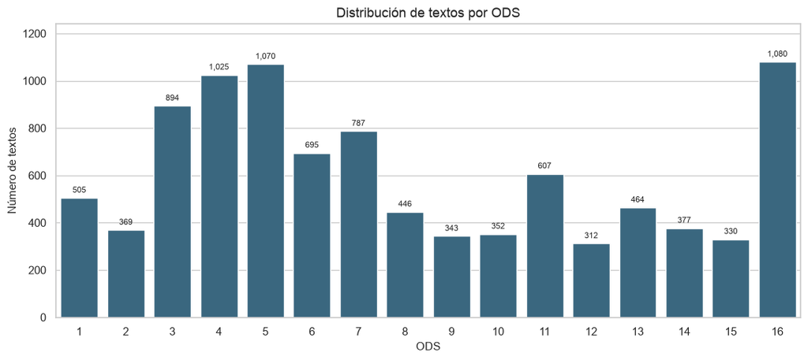

```python
conteo_ods = df["ODS"].value_counts().sort_index()
distribucion_ods = pd.DataFrame({
    "cantidad": conteo_ods,
    "porcentaje": (conteo_ods / len(df) * 100).round(2),
})
distribucion_ods.index.name = "ODS"

display(distribucion_ods)

ods_esperados = set(range(1, 18))
ods_presentes = set(map(int, conteo_ods.index))
print("ODS presentes:", sorted(ods_presentes))
print("ODS ausentes:", sorted(ods_esperados - ods_presentes))
print(f"Relación clase mayor / clase menor: {conteo_ods.max() / conteo_ods.min():.2f}")

fig, ax = plt.subplots(figsize=(11, 5))
sns.barplot(x=conteo_ods.index.astype(str), y=conteo_ods.values, color="#2F6B8A", ax=ax)
ax.set(title="Distribución de textos por ODS", xlabel="ODS", ylabel="Número de textos")
for i, value in enumerate(conteo_ods.values):
    ax.text(i, value + 15, f"{value:,}", ha="center", va="bottom", fontsize=8)
ax.set_ylim(0, conteo_ods.max() * 1.15)
plt.tight_layout()
plt.show()
```

### Interpretación de la distribución

El conjunto contiene etiquetas para los ODS 1 a 16, pero no para el ODS 17. Por ello, con esta fuente no es posible entrenar ni evaluar una clase 17. El soporte también varía entre las clases; en las siguientes fases se utilizará una partición estratificada y F1 macro como métrica principal para dar el mismo peso a cada ODS.

## 5. Longitud de los textos

Se miden caracteres y palabras. Las longitudes extremas pueden revelar registros truncados, textos anormalmente breves o documentos que requieran un tratamiento distinto.

|  | n_caracteres | n_palabras |
| --- | --- | --- |
| count | 9656.0 | 9656.0 |
| mean | 709.0 | 111.5 |
| std | 238.9 | 37.2 |
| min | 143.0 | 24.0 |
| 1% | 334.0 | 52.0 |
| 5% | 388.0 | 61.0 |
| 25% | 522.0 | 82.0 |
| 50% | 669.0 | 106.0 |
| 75% | 864.0 | 136.0 |
| 95% | 1153.0 | 179.0 |
| 99% | 1330.5 | 210.0 |
| max | 1977.0 | 268.0 |

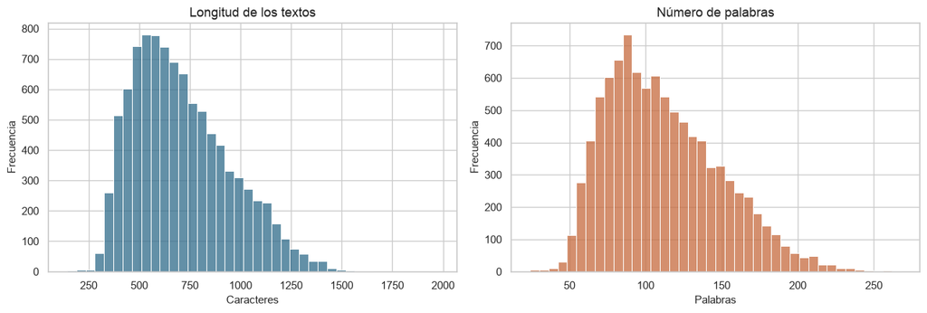

| ODS | count | median | mean | min | max |
| --- | --- | --- | --- | --- | --- |
| 1 | 505 | 106.0 | 111.2 | 50 | 260 |
| 2 | 369 | 104.0 | 107.3 | 52 | 221 |
| 3 | 894 | 103.0 | 108.6 | 44 | 244 |
| 4 | 1025 | 100.0 | 107.0 | 48 | 258 |
| 5 | 1070 | 109.0 | 115.3 | 39 | 245 |
| 6 | 695 | 104.0 | 109.0 | 46 | 239 |
| 7 | 787 | 103.0 | 108.9 | 52 | 234 |
| 8 | 446 | 102.0 | 109.3 | 50 | 255 |
| 9 | 343 | 93.0 | 99.4 | 39 | 237 |
| 10 | 352 | 95.0 | 102.3 | 42 | 223 |
| 11 | 607 | 100.0 | 107.0 | 47 | 222 |
| 12 | 312 | 78.0 | 85.2 | 25 | 210 |
| 13 | 464 | 109.0 | 114.4 | 52 | 259 |
| 14 | 377 | 94.0 | 102.5 | 43 | 248 |
| 15 | 330 | 92.5 | 96.6 | 40 | 209 |
| 16 | 1080 | 150.0 | 144.0 | 24 | 268 |

```python
df["n_caracteres"] = df["textos"].str.len()
df["n_palabras"] = df["textos"].str.findall(r"(?u)\b\w+\b").str.len()

percentiles = [0.01, 0.05, 0.25, 0.50, 0.75, 0.95, 0.99]
display(df[["n_caracteres", "n_palabras"]].describe(percentiles=percentiles).round(1))

fig, axes = plt.subplots(1, 2, figsize=(13, 4.5))
sns.histplot(df["n_caracteres"], bins=40, color="#2F6B8A", ax=axes[0])
axes[0].set(title="Longitud de los textos", xlabel="Caracteres", ylabel="Frecuencia")

sns.histplot(df["n_palabras"], bins=40, color="#C66A3D", ax=axes[1])
axes[1].set(title="Número de palabras", xlabel="Palabras", ylabel="Frecuencia")
plt.tight_layout()
plt.show()

longitud_por_ods = df.groupby("ODS")["n_palabras"].agg(["count", "median", "mean", "min", "max"]).round(1)
display(longitud_por_ods)
```

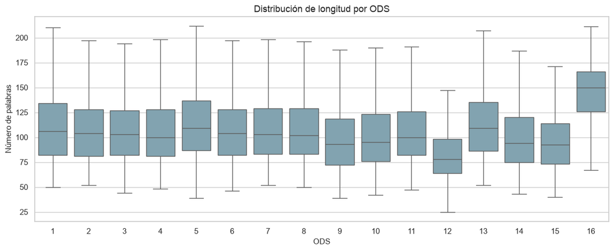

**Textos más breves**

|  | ODS | n_palabras | textos |
| --- | --- | --- | --- |
| 4774 | 16 | 24 | El capítulo examina la contribución que la teo... |
| 3713 | 12 | 25 | Ambiente finlandés (2009), Towards a Recycling... |
| 3238 | 16 | 27 | Un artículo sobre el alcance geográfico de las... |
| 5438 | 16 | 27 | La investigación de homicidios es una de las t... |
| 6828 | 16 | 27 | ¿Cómo afecta la corrupción política percibida ... |

**Textos más extensos**

|  | ODS | n_palabras | textos |
| --- | --- | --- | --- |
| 1978 | 16 | 268 | 1. Los derechos humanos internacionales y el r... |
| 2155 | 1 | 260 | Paraguay fue el país que tuvo más éxito en la ... |
| 6482 | 13 | 259 | Por ejemplo, el Inventario de Fondos Climático... |
| 3958 | 4 | 258 | El cuarenta y tres por ciento de las personas ... |
| 4288 | 8 | 255 | La tasa agregada esconde grandes diferencias p... |

```python
fig, ax = plt.subplots(figsize=(12, 5))
sns.boxplot(data=df, x="ODS", y="n_palabras", color="#7AA6B8", showfliers=False, ax=ax)
ax.set(title="Distribución de longitud por ODS", xlabel="ODS", ylabel="Número de palabras")
plt.tight_layout()
plt.show()

display(Markdown("**Textos más breves**"))
display(df.nsmallest(5, "n_palabras")[["ODS", "n_palabras", "textos"]])

display(Markdown("**Textos más extensos**"))
display(df.nlargest(5, "n_palabras")[["ODS", "n_palabras", "textos"]])
```

## 6. Indicadores básicos de calidad textual

Estos indicadores no determinan por sí solos que un texto sea defectuoso. Sirven para localizar elementos que conviene revisar antes de definir el preprocesamiento: enlaces, saltos de línea, caracteres de reemplazo, exceso de espacios o predominio inusual de dígitos.

```python
texto = df["textos"].astype(str)
indicadores_texto = pd.Series({
    "Contienen URL": texto.str.contains(r"https?://|www\.", case=False, regex=True).sum(),
    "Contienen salto de línea": texto.str.contains(r"[\r\n]", regex=True).sum(),
    "Contienen carácter de reemplazo (�)": texto.str.contains("�", regex=False).sum(),
    "Contienen espacios repetidos": texto.str.contains(r" {2,}", regex=True).sum(),
    "Empiezan o terminan con espacios": texto.ne(texto.str.strip()).sum(),
    "Más de 20 % de caracteres son dígitos": (
        texto.str.count(r"\d") / texto.str.len().clip(lower=1) > 0.20
    ).sum(),
}, name="Cantidad").to_frame()

display(indicadores_texto)

caracteres_no_comunes = sorted(set("".join(texto)) - set(
    "abcdefghijklmnopqrstuvwxyzABCDEFGHIJKLMNOPQRSTUVWXYZ0123456789 "
    "áéíóúÁÉÍÓÚüÜñÑ.,;:¿?¡!()[]{}%/-_+*=\"'@#&<>\n\r\t°ºª€$"
))
print("Muestra de caracteres menos comunes:", caracteres_no_comunes[:80])
```

|  | Cantidad |
| --- | --- |
| Contienen URL | 69 |
| Contienen salto de línea | 3 |
| Contienen carácter de reemplazo (�) | 0 |
| Contienen espacios repetidos | 19 |
| Empiezan o terminan con espacios | 305 |
| Más de 20 % de caracteres son dígitos | 0 |

```
Muestra de caracteres menos comunes: ['\\', '^', '|', '~', '\xa0', '¢', '£', '¦', '§', '©', '«', '¬', '®', '±', '»', '½', 'Ë', 'à', 'â', 'ã', 'ä', 'ç', '\u200b', '–', '—', '“', '”', '†', '•', '…', '™', '♦', '⤠', '⤽']
```

## 7. Revisión de ejemplos por clase

Se seleccionan dos textos por ODS con semilla fija. Esta revisión ayuda a comprobar si las etiquetas parecen razonables y si aparecen patrones de traducción, plantillas o ruido. Para facilitar la lectura se muestra una versión abreviada, sin modificar los datos originales.

```python
muestra_por_ods = (
    df.groupby("ODS", group_keys=False)
      .sample(n=2, random_state=SEED)
      .sort_values("ODS")
      [["ODS", "textos"]]
      .copy()
)
muestra_por_ods["texto_abreviado"] = muestra_por_ods["textos"].str.replace(r"\s+", " ", regex=True).str.slice(0, 350)
muestra_por_ods["texto_abreviado"] += np.where(muestra_por_ods["textos"].str.len() > 350, "…", "")
display(muestra_por_ods[["ODS", "texto_abreviado"]].reset_index(drop=True))
```

|  | ODS | texto_abreviado |
| --- | --- | --- |
| 0 | 1 | En tres (Chile, Perú y Uruguay), el efecto de ... |
| 1 | 1 | Por ejemplo, con el umbral de pobreza definido... |
| 2 | 2 | Las barras y los rombos indican los rangos y l... |
| 3 | 2 | La "fórmula de éxito" para Matsentralen es sin... |
| 4 | 3 | Esto contrasta con otros modelos que no incluy... |
| 5 | 3 | La ley anterior tenía una serie de deficiencia... |
| 6 | 4 | Para garantizar la calidad de la EAPI, el pers... |
| 7 | 4 | Los supervisores están destinados a visitar y ... |
| 8 | 5 | En respuesta a estos desafíos, los países han ... |
| 9 | 5 | Se trata de un avance positivo. Sin embargo, e... |
| 10 | 6 | Esta solución puede ser adecuada para una masa... |
| 11 | 6 | También se han realizado avances significativo... |
| 12 | 7 | El informe demuestra el caso comercial del uso... |
| 13 | 7 | El desarrollo de las instalaciones fotovoltaic... |
| 14 | 8 | La EPA busca dar forma a un espacio cultural c... |
| 15 | 8 | Al fin y al cabo, las infraestructuras necesar... |
| 16 | 9 | El cuarto plan móvil de 5 años, Smart Rwanda M... |
| 17 | 9 | La tasa aumenta con el tiempo y, finalmente, u... |
| 18 | 10 | Es necesario que los formuladores de políticas... |
| 19 | 10 | Estonia, Irlanda y España registraron los mayo... |
| 20 | 11 | Se puede suponer que los ocupantes del automóv... |
| 21 | 11 | Se han implementado diferentes medidas para re... |
| 22 | 12 | Sin embargo, alrededor del 40 % del pescado se... |
| 23 | 12 | Los objetivos de la estrategia son sensibiliza... |
| 24 | 13 | Esto se basa en múltiples líneas de pruebas, i... |
| 25 | 13 | Este documento esboza los cambios previstos en... |
| 26 | 14 | El total de las exportaciones pesqueras en 200... |
| 27 | 14 | No podemos seguir así. El precio que recibimos... |
| 28 | 15 | Para abordar el calentamiento global y la pérd... |
| 29 | 15 | Más del 80 % del área forestal delimitada Natu... |
| 30 | 16 | Los problemas de seguridad "no tradicionales",... |
| 31 | 16 | En este trabajo, analizo material diverso prod... |

## 8. Búsqueda de textos aproximadamente duplicados

Los datos fueron traducidos y aumentados, por lo que dos textos pueden ser muy parecidos sin ser copias exactas. Para detectar estos casos se construye una representación TF-IDF de caracteres y se busca el vecino más cercano de cada registro mediante similitud coseno.

Esta representación es deliberadamente independiente del pipeline de clasificación. Su única función es identificar un posible riesgo de fuga entre entrenamiento y prueba.

```
Matriz de auditoría: 9,656 textos × 30,000 características
```

|  | umbral_similitud | textos_con_vecino_sobre_umbral |
| --- | --- | --- |
| 0 | 0.80 | 19 |
| 1 | 0.85 | 13 |
| 2 | 0.90 | 6 |
| 3 | 0.95 | 0 |
| 4 | 0.99 | 0 |

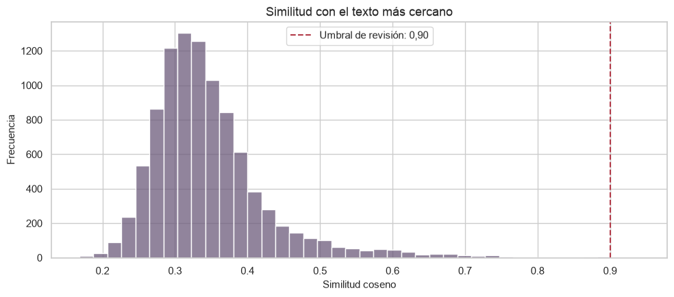

```python
vectorizador_auditoria = TfidfVectorizer(
    analyzer="char_wb",
    ngram_range=(3, 5),
    min_df=2,
    max_features=30_000,
    sublinear_tf=True,
    dtype=np.float32,
)
X_auditoria = vectorizador_auditoria.fit_transform(df["texto_normalizado_auditoria"])

print(f"Matriz de auditoría: {X_auditoria.shape[0]:,} textos × {X_auditoria.shape[1]:,} características")

vecinos = NearestNeighbors(n_neighbors=2, metric="cosine", algorithm="brute", n_jobs=-1)
vecinos.fit(X_auditoria)

with config_context(working_memory=256):
    distancias, indices = vecinos.kneighbors(X_auditoria, return_distance=True)

df["indice_vecino"] = indices[:, 1]
df["similitud_vecino"] = 1 - distancias[:, 1]
df["ods_vecino"] = df.iloc[df["indice_vecino"]]["ODS"].to_numpy()

resumen_similitud = pd.DataFrame({
    "umbral_similitud": [0.80, 0.85, 0.90, 0.95, 0.99],
    "textos_con_vecino_sobre_umbral": [
        int((df["similitud_vecino"] >= umbral).sum())
        for umbral in [0.80, 0.85, 0.90, 0.95, 0.99]
    ],
})
display(resumen_similitud)

fig, ax = plt.subplots(figsize=(10, 4.5))
sns.histplot(df["similitud_vecino"], bins=40, color="#6C5B7B", ax=ax)
ax.axvline(0.90, color="#B23A48", linestyle="--", label="Umbral de revisión: 0,90")
ax.set(title="Similitud con el texto más cercano", xlabel="Similitud coseno", ylabel="Frecuencia")
ax.legend()
plt.tight_layout()
plt.show()
```

```python
pares = []
vistos = set()
for i, fila in df.loc[df["similitud_vecino"] >= 0.90].iterrows():
    j = int(fila["indice_vecino"])
    clave = tuple(sorted((int(i), j)))
    if clave in vistos:
        continue
    vistos.add(clave)
    pares.append({
        "indice_1": clave[0],
        "indice_2": clave[1],
        "similitud": float(fila["similitud_vecino"]),
        "ODS_1": int(df.loc[clave[0], "ODS"]),
        "ODS_2": int(df.loc[clave[1], "ODS"]),
        "misma_etiqueta": int(df.loc[clave[0], "ODS"]) == int(df.loc[clave[1], "ODS"]),
        "texto_1": re.sub(r"\s+", " ", df.loc[clave[0], "textos"])[:250],
        "texto_2": re.sub(r"\s+", " ", df.loc[clave[1], "textos"])[:250],
    })

pares_similares = pd.DataFrame(pares).sort_values("similitud", ascending=False) if pares else pd.DataFrame()

print(f"Pares únicos con similitud ≥ 0,90: {len(pares_similares):,}")
if not pares_similares.empty:
    print(f"Pares con etiquetas diferentes: {(~pares_similares['misma_etiqueta']).sum():,}")
    display(pares_similares.head(20))
else:
    print("No se encontraron pares por encima del umbral seleccionado.")
```

```
Pares únicos con similitud ≥ 0,90: 3
Pares con etiquetas diferentes: 0
```

|  | indice_1 | indice_2 | similitud | ODS_1 | ODS_2 | misma_etiqueta | texto_1 | texto_2 |
| --- | --- | --- | --- | --- | --- | --- | --- | --- |
| 2 | 3232 | 6097 | 0.940175 | 14 | 14 | True | Los números de 'Transferencias al SECTOR' info... | Las cifras de Transferencias al SECTOR que se ... |
| 1 | 406 | 4783 | 0.921967 | 13 | 13 | True | El CCXG (anteriormente llamado Grupo de Expert... | El CCXG (anteriormente llamado Grupo de Expert... |
| 0 | 400 | 4339 | 0.916333 | 13 | 13 | True | Ciertamente, si la ambición de las NDC se incr... | Ambos conjuntos de implicaciones se examinan a... |

## 9. Resumen automático de la auditoría

La siguiente celda reúne los hallazgos que condicionan las decisiones de las próximas fases.

```python
n_pares_90 = len(pares_similares)
n_conflictos_90 = int((~pares_similares["misma_etiqueta"]).sum()) if n_pares_90 else 0

hallazgos = [
    f"El conjunto contiene {len(df):,} textos y {df['ODS'].nunique()} clases.",
    f"No hay valores nulos en textos: {df['textos'].isna().sum()} ni en etiquetas: {df['ODS'].isna().sum()}.",
    f"Se encontraron {df['textos'].duplicated(keep=False).sum()} textos duplicados exactos.",
    f"Después de normalizar formato se encontraron {df['texto_normalizado_auditoria'].duplicated(keep=False).sum()} textos en grupos duplicados.",
    f"Los ODS ausentes son: {sorted(ods_esperados - ods_presentes)}.",
    f"La clase mayor contiene {conteo_ods.max():,} textos y la menor {conteo_ods.min():,}; la relación es {conteo_ods.max()/conteo_ods.min():.2f}.",
    f"La longitud mediana es {df['n_palabras'].median():.0f} palabras; el rango va de {df['n_palabras'].min()} a {df['n_palabras'].max()} palabras.",
    f"Hay {n_pares_90:,} pares únicos con similitud coseno de al menos 0,90; {n_conflictos_90:,} tienen etiquetas diferentes.",
]

display(Markdown("\n".join(f"- {h}" for h in hallazgos)))
```

- El conjunto contiene 9,656 textos y 16 clases.

- No hay valores nulos en textos: 0 ni en etiquetas: 0.

- Se encontraron 0 textos duplicados exactos.

- Después de normalizar formato se encontraron 0 textos en grupos duplicados.

- Los ODS ausentes son: [17].

- La clase mayor contiene 1,080 textos y la menor 312; la relación es 3.46.

- La longitud mediana es 106 palabras; el rango va de 24 a 268 palabras.

- Hay 3 pares únicos con similitud coseno de al menos 0,90; 0 tienen etiquetas diferentes.

## 10. Decisiones derivadas de la fase 1

1. **Alcance de etiquetas:** el modelo se entrenará con los ODS 1 a 16. No se afirmará que puede predecir el ODS 17 mientras no existan ejemplos etiquetados para esa clase.
2. **Métrica y partición:** la clase mayor tiene 3,46 veces el soporte de la menor. Se utilizará partición estratificada y F1 macro como métrica principal.
3. **Fuga por similitud:** se encontraron tres pares únicos con similitud mayor o igual a 0,90. Todos comparten la misma etiqueta, pero sus miembros deberán permanecer en el mismo grupo al dividir los datos para que versiones casi idénticas no aparezcan en entrenamiento y prueba.
4. **Calidad textual:** hay 69 textos con URL, 305 con espacios en los extremos y 19 con espacios repetidos. Se normalizarán espacios y se evaluará el tratamiento de las URL dentro del pipeline, sin eliminar información de forma indiscriminada.
5. **Longitud:** la mediana es de 106 palabras y el rango observado va de 24 a 268. No se encontraron textos vacíos ni longitudes que exijan truncamiento para el enfoque TF-IDF.
6. **Preprocesamiento:** no se aplicará una limpieza agresiva. La normalización usada para auditar duplicados no sustituye el pipeline TF-IDF del modelo.
7. **Trazabilidad:** se conservarán los textos originales y sus índices. Las columnas auxiliares creadas en esta fase son diagnósticas.

Con estas condiciones documentadas, la siguiente fase será definir una partición de desarrollo/prueba libre de fuga y construir la representación TF-IDF dentro de un pipeline.

## Cierre de la fase 1

La auditoría anterior define las condiciones que debe respetar la partición: conservar la proporción de clases, mantener juntos los textos muy similares y reservar el conjunto de prueba para la evaluación final.

# Fase 2: separación de entrenamiento y prueba

El objetivo de esta fase es congelar una partición reproducible antes de ajustar TF-IDF, SVD o cualquier clasificador. Se reserva el 20 % de las observaciones para la evaluación final y se utiliza el 80 % restante para entrenamiento, validación cruzada y selección de hiperparámetros.

La división debe cumplir dos condiciones:

1. **Estratificación:** conservar aproximadamente la proporción de cada ODS.
2. **Control de similitud:** mantener dentro de una misma partición los textos conectados por una similitud coseno mayor o igual a 0,90.

Para satisfacer ambas condiciones, la unidad de partición no será cada fila individual, sino cada grupo de textos similares. Los grupos se estratifican según su etiqueta ODS.

## 11. Construcción de grupos de similitud

Se utiliza una estructura de conjuntos disjuntos para unir los índices de cada par similar detectado en la fase 1. Los registros que no pertenecen a ningún par forman un grupo individual. Antes de dividir se comprueba que cada grupo tenga una única etiqueta.

```python
class UnionFind:
    def __init__(self, elementos):
        self.parent = {int(x): int(x) for x in elementos}

    def find(self, x):
        x = int(x)
        if self.parent[x] != x:
            self.parent[x] = self.find(self.parent[x])
        return self.parent[x]

    def union(self, a, b):
        raiz_a, raiz_b = self.find(a), self.find(b)
        if raiz_a != raiz_b:
            self.parent[max(raiz_a, raiz_b)] = min(raiz_a, raiz_b)


union_find = UnionFind(df.index)
if not pares_similares.empty:
    for fila in pares_similares.itertuples(index=False):
        union_find.union(fila.indice_1, fila.indice_2)

df["grupo_similitud"] = [union_find.find(i) for i in df.index]

resumen_grupos = (
    df.groupby("grupo_similitud")
      .agg(ODS=("ODS", "first"), tamanio=("ODS", "size"), etiquetas=("ODS", "nunique"))
      .reset_index()
)

assert resumen_grupos["etiquetas"].eq(1).all(), (
    "Hay grupos similares con etiquetas distintas; deben revisarse antes de dividir."
)

print(f"Número de grupos: {len(resumen_grupos):,}")
print(f"Grupos con más de un texto: {(resumen_grupos['tamanio'] > 1).sum():,}")
display(resumen_grupos["tamanio"].value_counts().sort_index().rename("numero_grupos").to_frame())
```

```
Número de grupos: 9,653
Grupos con más de un texto: 3
```

| tamanio | numero_grupos |
| --- | --- |
| 1 | 9650 |
| 2 | 3 |

## 12. Partición estratificada a nivel de grupo

Se aplica `train_test_split` sobre la tabla de grupos, estratificando por ODS. De esta forma ningún grupo se fragmenta. La semilla fija permite reconstruir exactamente la misma partición.

```python
from sklearn.model_selection import train_test_split

TEST_SIZE = 0.20

grupos_train, grupos_test = train_test_split(
    resumen_grupos,
    test_size=TEST_SIZE,
    random_state=SEED,
    stratify=resumen_grupos["ODS"],
)

ids_train = set(grupos_train["grupo_similitud"])
ids_test = set(grupos_test["grupo_similitud"])

df["particion"] = np.where(df["grupo_similitud"].isin(ids_test), "test", "train")

train_idx = df.index[df["particion"].eq("train")].to_numpy()
test_idx = df.index[df["particion"].eq("test")].to_numpy()

X_train = df.loc[train_idx, "textos"].copy()
y_train = df.loc[train_idx, "ODS"].copy()
X_test = df.loc[test_idx, "textos"].copy()
y_test = df.loc[test_idx, "ODS"].copy()

resumen_particion = pd.DataFrame({
    "registros": [len(X_train), len(X_test), len(df)],
    "porcentaje": [len(X_train) / len(df) * 100, len(X_test) / len(df) * 100, 100.0],
    "grupos": [len(ids_train), len(ids_test), len(ids_train | ids_test)],
}, index=["train", "test", "total"])

display(resumen_particion.round(2))
```

|  | registros | porcentaje | grupos |
| --- | --- | --- | --- |
| train | 7724 | 79.99 | 7722 |
| test | 1932 | 20.01 | 1931 |
| total | 9656 | 100.00 | 9653 |

## 13. Verificación de estratificación

Se comparan las proporciones de cada ODS en el conjunto completo, entrenamiento y prueba. La diferencia se expresa en puntos porcentuales. Una desviación pequeña confirma que el muestreo por grupos conserva adecuadamente la distribución original.

| ODS | total | train | test | diferencia_test_total_pp |
| --- | --- | --- | --- | --- |
| 1 | 5.23 | 5.23 | 5.23 | -0.00 |
| 2 | 3.82 | 3.82 | 3.83 | 0.01 |
| 3 | 9.26 | 9.26 | 9.27 | 0.01 |
| 4 | 10.62 | 10.62 | 10.61 | -0.00 |
| 5 | 11.08 | 11.08 | 11.08 | -0.00 |
| 6 | 7.20 | 7.20 | 7.19 | -0.00 |
| 7 | 8.15 | 8.14 | 8.18 | 0.03 |
| 8 | 4.62 | 4.62 | 4.61 | -0.01 |
| 9 | 3.55 | 3.55 | 3.57 | 0.02 |
| 10 | 3.65 | 3.65 | 3.62 | -0.02 |
| 11 | 6.29 | 6.28 | 6.31 | 0.03 |
| 12 | 3.23 | 3.24 | 3.21 | -0.02 |
| 13 | 4.81 | 4.80 | 4.81 | 0.01 |
| 14 | 3.90 | 3.91 | 3.88 | -0.02 |
| 15 | 3.42 | 3.42 | 3.42 | -0.00 |
| 16 | 11.18 | 11.19 | 11.18 | -0.00 |

| particion ODS | test | train |
| --- | --- | --- |
| 1 | 101 | 404 |
| 2 | 74 | 295 |
| 3 | 179 | 715 |
| 4 | 205 | 820 |
| 5 | 214 | 856 |
| 6 | 139 | 556 |
| 7 | 158 | 629 |
| 8 | 89 | 357 |
| 9 | 69 | 274 |
| 10 | 70 | 282 |
| 11 | 122 | 485 |
| 12 | 62 | 250 |
| 13 | 93 | 371 |
| 14 | 75 | 302 |
| 15 | 66 | 264 |
| 16 | 216 | 864 |

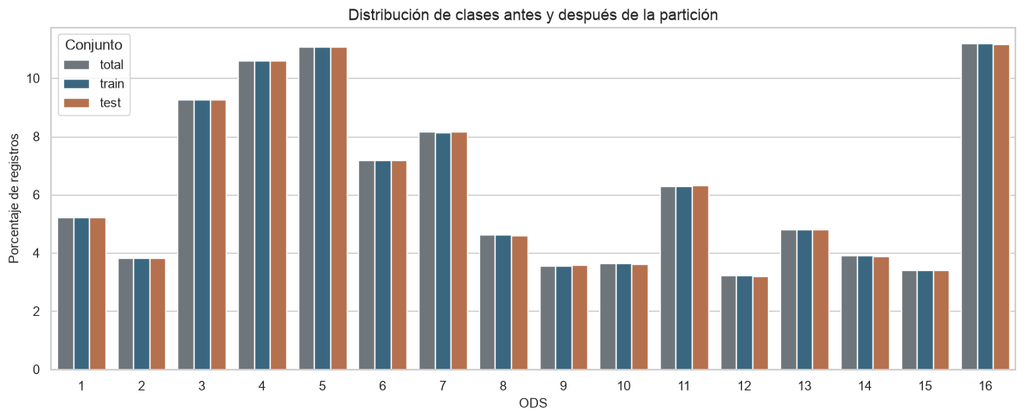

```
Máxima desviación absoluta en prueba: 0.028 puntos porcentuales
```

```python
distribucion_split = pd.concat({
    "total": df["ODS"].value_counts(normalize=True).sort_index() * 100,
    "train": y_train.value_counts(normalize=True).sort_index() * 100,
    "test": y_test.value_counts(normalize=True).sort_index() * 100,
}, axis=1)

distribucion_split["diferencia_test_total_pp"] = (
    distribucion_split["test"] - distribucion_split["total"]
)
display(distribucion_split.round(2))

conteos_split = pd.crosstab(df["ODS"], df["particion"])
display(conteos_split)

fig, ax = plt.subplots(figsize=(12, 5))
distribucion_grafico = (
    distribucion_split[["total", "train", "test"]]
    .reset_index()
    .melt(id_vars="ODS", var_name="conjunto", value_name="porcentaje")
)
sns.barplot(
    data=distribucion_grafico,
    x="ODS",
    y="porcentaje",
    hue="conjunto",
    palette=["#6C757D", "#2F6B8A", "#C66A3D"],
    ax=ax,
)
ax.set(
    title="Distribución de clases antes y después de la partición",
    xlabel="ODS",
    ylabel="Porcentaje de registros",
)
ax.legend(title="Conjunto")
plt.tight_layout()
plt.show()

max_desviacion = distribucion_split["diferencia_test_total_pp"].abs().max()
print(f"Máxima desviación absoluta en prueba: {max_desviacion:.3f} puntos porcentuales")
```

## 14. Controles de fuga e integridad

Las siguientes aserciones convierten los requisitos de la partición en pruebas ejecutables. El notebook se detendrá si una fila aparece en ambos conjuntos, si un grupo se divide, si falta alguna clase o si uno de los pares similares cruza la frontera entrenamiento-prueba.

```python
# Cobertura y exclusión mutua de filas
assert len(train_idx) + len(test_idx) == len(df)
assert set(train_idx).isdisjoint(set(test_idx))
assert set(train_idx) | set(test_idx) == set(df.index)

# Exclusión mutua de grupos
assert ids_train.isdisjoint(ids_test)

# Todas las clases disponibles deben estar representadas en ambos conjuntos
assert set(y_train.unique()) == ods_presentes
assert set(y_test.unique()) == ods_presentes

# Ningún par de alta similitud puede cruzar la partición
pares_cruzados = []
if not pares_similares.empty:
    for fila in pares_similares.itertuples(index=False):
        split_1 = df.loc[fila.indice_1, "particion"]
        split_2 = df.loc[fila.indice_2, "particion"]
        if split_1 != split_2:
            pares_cruzados.append((fila.indice_1, fila.indice_2))

assert not pares_cruzados, f"Pares similares separados: {pares_cruzados}"

controles = pd.Series({
    "Filas cubiertas exactamente una vez": True,
    "Índices train/test disjuntos": set(train_idx).isdisjoint(set(test_idx)),
    "Grupos train/test disjuntos": ids_train.isdisjoint(ids_test),
    "Todas las clases presentes en train": set(y_train.unique()) == ods_presentes,
    "Todas las clases presentes en test": set(y_test.unique()) == ods_presentes,
    "Pares similares que cruzan la partición": len(pares_cruzados),
}, name="Resultado").to_frame()

display(controles)
print("Todos los controles de integridad fueron superados.")
```

|  | Resultado |
| --- | --- |
| Filas cubiertas exactamente una vez | True |
| Índices train/test disjuntos | True |
| Grupos train/test disjuntos | True |
| Todas las clases presentes en train | True |
| Todas las clases presentes en test | True |
| Pares similares que cruzan la partición | 0 |

```
Todos los controles de integridad fueron superados.
```

## 15. Persistencia de la partición

Se guarda un manifiesto con el identificador de fila, la etiqueta, el grupo y la partición asignada. Este archivo permite reutilizar exactamente la misma separación en todas las fases. También se calcula la huella SHA-256 del Excel original para detectar si la fuente cambia.

```python
import hashlib

huella_datos = hashlib.sha256(DATA_PATH.read_bytes()).hexdigest()
SPLIT_PATH = PROJECT_ROOT / "data" / "particion_train_test.csv"

manifiesto_split = (
    df[["ODS", "grupo_similitud", "particion"]]
    .rename_axis("row_id")
    .reset_index()
    .sort_values("row_id")
)
manifiesto_split.to_csv(SPLIT_PATH, index=False)

manifiesto_verificado = pd.read_csv(SPLIT_PATH)
assert len(manifiesto_verificado) == len(df)
assert manifiesto_verificado["row_id"].is_unique
assert set(manifiesto_verificado["particion"]) == {"train", "test"}

print(f"Manifiesto guardado en: {SPLIT_PATH.relative_to(PROJECT_ROOT)}")
print(f"Huella SHA-256 del Excel: {huella_datos}")
display(manifiesto_split.head())
```

```
Manifiesto guardado en: data/particion_train_test.csv
Huella SHA-256 del Excel: 685f219c3741347e8d97341c29b84ebd3410952fcdcce61f4664ec67a1c0654d
```

|  | row_id | ODS | grupo_similitud | particion |
| --- | --- | --- | --- | --- |
| 0 | 0 | 4 | 0 | train |
| 1 | 1 | 6 | 1 | train |
| 2 | 2 | 13 | 2 | train |
| 3 | 3 | 16 | 3 | train |
| 4 | 4 | 5 | 4 | train |

## 16. Resultado y reglas para las fases siguientes

La partición queda congelada con una proporción aproximada de 80 % para entrenamiento y 20 % para prueba. Todos los ODS disponibles aparecen en ambos conjuntos y ningún par con similitud mayor o igual a 0,90 cruza entre ellos.

A partir de este punto:

- `X_train` y `y_train` se utilizarán para análisis que aprendan parámetros, validación cruzada y búsqueda de hiperparámetros.
- `X_test` y `y_test` permanecerán sin transformar ni evaluar hasta seleccionar el modelo final.
- TF-IDF, SVD y el clasificador se ajustarán dentro de pipelines usando únicamente entrenamiento.
- La prueba final se ejecutará una sola vez y sus resultados no se utilizarán para volver a seleccionar hiperparámetros.
- Si cambia el archivo fuente, se verificará su huella y se reconstruirá la partición.

La siguiente fase será diseñar la preparación del texto y la representación TF-IDF dentro de un pipeline sin fuga de información.

## Cierre de la fase 2

La partición está congelada y verificada. Desde este punto, todas las transformaciones que aprendan parámetros se ajustan exclusivamente sobre `X_train`.

# Fase 3: preparación del texto y representación TF-IDF

Esta fase convierte los textos en una matriz numérica mediante bolsa de palabras ponderada con TF-IDF. La preparación se mantiene deliberadamente moderada para conservar términos que pueden distinguir los ODS.

Las decisiones iniciales son:

- Convertir a minúsculas dentro de `TfidfVectorizer`.
- Sustituir URLs completas por el token `url`.
- Normalizar espacios y saltos de línea.
- Conservar tildes y la letra ñ.
- Conservar unigramas y evaluar bigramas.
- Descartar términos excesivamente raros con `min_df` y términos presentes en casi todos los documentos con `max_df`.
- Aplicar frecuencia de término sublineal para reducir el dominio de las repeticiones.
- No aplicar lematización ni eliminación manual de *stopwords* en esta etapa.

El vocabulario y los pesos IDF se aprenden solo con entrenamiento. El conjunto de prueba permanece reservado.

## 17. Transformación de limpieza

La función recibe un corpus y devuelve textos con URLs y espacios normalizados. Se integra mediante `FunctionTransformer`, por lo que formará parte del mismo pipeline usado en validación y predicción.

```python
from sklearn.base import clone
from sklearn.pipeline import Pipeline
from sklearn.preprocessing import FunctionTransformer

PATRON_URL = re.compile(r"https?://\S+|www\.\S+", flags=re.IGNORECASE)
PATRON_ESPACIOS = re.compile(r"\s+")


def limpiar_corpus(corpus):
    textos_limpios = []
    for documento in corpus:
        documento = str(documento)
        documento = PATRON_URL.sub(" url ", documento)
        documento = PATRON_ESPACIOS.sub(" ", documento).strip()
        textos_limpios.append(documento)
    return textos_limpios


limpieza = FunctionTransformer(limpiar_corpus, validate=False, feature_names_out="one-to-one")

muestra_limpieza = pd.DataFrame({
    "original": X_train[X_train.str.contains(r"https?://|www\.", case=False, regex=True)].head(3),
})
muestra_limpieza["transformado"] = limpiar_corpus(muestra_limpieza["original"])
muestra_limpieza = muestra_limpieza.map(lambda x: x[:300] + ("…" if len(x) > 300 else ""))

display(muestra_limpieza)

train_limpio = limpiar_corpus(X_train)
print(f"Textos de entrenamiento procesados: {len(train_limpio):,}")
print(f"Textos vacíos después de la limpieza: {sum(not t for t in train_limpio):,}")
```

|  | original | transformado |
| --- | --- | --- |
| 300 | Los análisis de cohortes longitudinales basado... | Los análisis de cohortes longitudinales basado... |
| 309 | Los documentos pueden telecargarse a partir de... | Los documentos pueden telecargarse a partir de... |
| 399 | Las actividades son realizadas por una amplia ... | Las actividades son realizadas por una amplia ... |

```
Textos de entrenamiento procesados: 7,724
Textos vacíos después de la limpieza: 0
```

## 18. Comparación estructural de configuraciones TF-IDF

```python
from sklearn.feature_extraction.text import TfidfVectorizer


def memoria_matriz_mb(matriz):
    return (matriz.data.nbytes + matriz.indices.nbytes + matriz.indptr.nbytes) / 1024**2


configuraciones_tfidf = {
    "unigramas_min3": {
        "ngram_range": (1, 1),
        "min_df": 3,
        "max_df": 0.95,
    },
    "uni_bigramas_min3": {
        "ngram_range": (1, 2),
        "min_df": 3,
        "max_df": 0.95,
    },
    "uni_bigramas_min5": {
        "ngram_range": (1, 2),
        "min_df": 5,
        "max_df": 0.95,
    },
    "uni_bigramas_min3_max30": {
        "ngram_range": (1, 2),
        "min_df": 3,
        "max_df": 0.30,
    },
}

resultados_tfidf = []
for nombre, parametros in configuraciones_tfidf.items():
    vectorizador = TfidfVectorizer(
        lowercase=True,
        strip_accents=None,
        sublinear_tf=True,
        norm="l2",
        dtype=np.float32,
        token_pattern=r"(?u)\b\w\w+\b",
        **parametros,
    )
    matriz = vectorizador.fit_transform(train_limpio)
    resultados_tfidf.append({
        "configuracion": nombre,
        "documentos": matriz.shape[0],
        "caracteristicas": matriz.shape[1],
        "valores_no_cero": matriz.nnz,
        "no_ceros_por_documento": matriz.nnz / matriz.shape[0],
        "densidad_pct": matriz.nnz / (matriz.shape[0] * matriz.shape[1]) * 100,
        "memoria_mb": memoria_matriz_mb(matriz),
    })

comparacion_tfidf = pd.DataFrame(resultados_tfidf).set_index("configuracion")
display(comparacion_tfidf.round({
    "no_ceros_por_documento": 1,
    "densidad_pct": 4,
    "memoria_mb": 1,
}))
```

| configuracion | documentos | caracteristicas | valores_no_cero | no_ceros_por_documento | densidad_pct | memoria_mb |
| --- | --- | --- | --- | --- | --- | --- |
| unigramas_min3 | 7724 | 12311 | 489831 | 63.4 | 0.5151 | 3.8 |
| uni_bigramas_min3 | 7724 | 49533 | 988280 | 127.9 | 0.2583 | 7.6 |
| uni_bigramas_min5 | 7724 | 29048 | 919326 | 119.0 | 0.4097 | 7.0 |
| uni_bigramas_min3_max30 | 7724 | 49511 | 888245 | 115.0 | 0.2323 | 6.8 |

## 19. Pipeline TF-IDF inicial

Se adopta como configuración inicial unigramas y bigramas con `min_df=3` y `max_df=0.30`. Los bigramas preservan expresiones como “cambio climático”, “salud pública” o “agua potable”, que pueden ser más informativas que las palabras aisladas. `min_df=3` elimina términos que aparecen en menos de tres documentos.

La inspección con `max_df=0.95` mostró que los términos con mayor peso medio eran palabras funcionales como “en”, “los” y “el”. Reducir `max_df` a 0,30 elimina automáticamente los términos presentes en más del 30 % del entrenamiento y evita que dominen los componentes LSA. Este filtro se aprende dentro de cada ajuste del pipeline, sin usar una lista externa de *stopwords*.

Esta elección no queda fijada como óptima para clasificación. `ngram_range`, `min_df`, `max_df` y `sublinear_tf` permanecerán disponibles para la búsqueda de hiperparámetros.

```python
PARAMETROS_TFIDF_INICIALES = {
    "lowercase": True,
    "strip_accents": None,
    "ngram_range": (1, 2),
    "min_df": 3,
    "max_df": 0.30,
    "sublinear_tf": True,
    "norm": "l2",
    "dtype": np.float32,
    "token_pattern": r"(?u)\b\w\w+\b",
}

pipeline_tfidf = Pipeline([
    ("limpieza", FunctionTransformer(
        limpiar_corpus,
        validate=False,
        feature_names_out="one-to-one",
    )),
    ("tfidf", TfidfVectorizer(**PARAMETROS_TFIDF_INICIALES)),
])

X_train_tfidf = pipeline_tfidf.fit_transform(X_train)
vectorizador_tfidf = pipeline_tfidf.named_steps["tfidf"]
terminos_tfidf = vectorizador_tfidf.get_feature_names_out()

print(f"Matriz TF-IDF de entrenamiento: {X_train_tfidf.shape[0]:,} × {X_train_tfidf.shape[1]:,}")
print(f"Valores no cero: {X_train_tfidf.nnz:,}")
print(f"Densidad: {X_train_tfidf.nnz / np.prod(X_train_tfidf.shape) * 100:.4f} %")
print(f"Memoria de la matriz dispersa: {memoria_matriz_mb(X_train_tfidf):.1f} MB")
print(f"Documentos usados para ajustar el vocabulario: {len(X_train):,}")
print(f"Documentos de prueba usados para ajustar el vocabulario: 0")

assert X_train_tfidf.shape[0] == len(X_train)
assert X_train_tfidf.shape[1] == len(terminos_tfidf)
assert np.isfinite(X_train_tfidf.data).all()
assert (X_train_tfidf.getnnz(axis=1) > 0).all()
assert len(X_test) == 1_932, "El conjunto de prueba cambió inesperadamente."

print("Validaciones de la matriz superadas.")
```

```
Matriz TF-IDF de entrenamiento: 7,724 × 49,511
Valores no cero: 888,245
Densidad: 0.2323 %
Memoria de la matriz dispersa: 6.8 MB
Documentos usados para ajustar el vocabulario: 7,724
Documentos de prueba usados para ajustar el vocabulario: 0
Validaciones de la matriz superadas.
```

## 20. Inspección del vocabulario aprendido

Se inspeccionan los términos con mayor promedio TF-IDF y los de mayor frecuencia documental dentro de entrenamiento. Esta revisión permite detectar si el espacio está dominado por palabras funcionales o por expresiones semánticamente útiles.

```python
promedio_tfidf = np.asarray(X_train_tfidf.mean(axis=0)).ravel()
frecuencia_documental = np.asarray((X_train_tfidf > 0).sum(axis=0)).ravel()

top_promedio_idx = np.argsort(promedio_tfidf)[-25:][::-1]
top_frecuencia_idx = np.argsort(frecuencia_documental)[-25:][::-1]

top_promedio = pd.DataFrame({
    "termino": terminos_tfidf[top_promedio_idx],
    "tfidf_promedio": promedio_tfidf[top_promedio_idx],
    "documentos": frecuencia_documental[top_promedio_idx],
})

top_frecuencia = pd.DataFrame({
    "termino": terminos_tfidf[top_frecuencia_idx],
    "documentos": frecuencia_documental[top_frecuencia_idx],
    "porcentaje_documentos": frecuencia_documental[top_frecuencia_idx] / len(X_train) * 100,
})

display(Markdown("**Mayor promedio TF-IDF**"))
display(top_promedio.round(4))

display(Markdown("**Mayor frecuencia documental**"))
display(top_frecuencia.round(2))

n_unigramas = sum(" " not in termino for termino in terminos_tfidf)
n_bigramas = len(terminos_tfidf) - n_unigramas
print(f"Unigramas: {n_unigramas:,}")
print(f"Bigramas: {n_bigramas:,}")
```

**Mayor promedio TF-IDF**

|  | termino | tfidf_promedio | documentos |
| --- | --- | --- | --- |
| 0 | países | 0.0103 | 1717 |
| 1 | entre | 0.0103 | 1982 |
| 2 | sobre | 0.0102 | 1947 |
| 3 | su | 0.0096 | 1838 |
| 4 | también | 0.0095 | 1903 |
| 5 | este | 0.0092 | 1858 |
| 6 | ha | 0.0089 | 1529 |
| 7 | lo | 0.0089 | 1692 |
| 8 | desarrollo | 0.0087 | 1432 |
| 9 | en los | 0.0087 | 1621 |
| 10 | son | 0.0085 | 1558 |
| 11 | mujeres | 0.0084 | 842 |
| 12 | sin | 0.0081 | 1519 |
| 13 | pueden | 0.0076 | 1277 |
| 14 | sus | 0.0076 | 1270 |
| 15 | han | 0.0074 | 1197 |
| 16 | puede | 0.0072 | 1190 |
| 17 | agua | 0.0071 | 641 |
| 18 | que los | 0.0071 | 1204 |
| 19 | en las | 0.0070 | 1202 |
| 20 | para la | 0.0069 | 1173 |
| 21 | políticas | 0.0068 | 992 |
| 22 | los países | 0.0067 | 997 |
| 23 | las mujeres | 0.0066 | 686 |
| 24 | embargo | 0.0065 | 1158 |

**Mayor frecuencia documental**

|  | termino | documentos | porcentaje_documentos |
| --- | --- | --- | --- |
| 0 | entre | 1982 | 25.66 |
| 1 | sobre | 1947 | 25.21 |
| 2 | también | 1903 | 24.64 |
| 3 | este | 1858 | 24.05 |
| 4 | su | 1838 | 23.80 |
| 5 | países | 1717 | 22.23 |
| 6 | lo | 1692 | 21.91 |
| 7 | en los | 1621 | 20.99 |
| 8 | son | 1558 | 20.17 |
| 9 | ha | 1529 | 19.80 |
| 10 | sin | 1519 | 19.67 |
| 11 | desarrollo | 1432 | 18.54 |
| 12 | pueden | 1277 | 16.53 |
| 13 | sus | 1270 | 16.44 |
| 14 | que los | 1204 | 15.59 |
| 15 | en las | 1202 | 15.56 |
| 16 | han | 1197 | 15.50 |
| 17 | puede | 1190 | 15.41 |
| 18 | para la | 1173 | 15.19 |
| 19 | embargo | 1158 | 14.99 |
| 20 | sin embargo | 1157 | 14.98 |
| 21 | que la | 1122 | 14.53 |
| 22 | que se | 1091 | 14.12 |
| 23 | esto | 1058 | 13.70 |
| 24 | ejemplo | 1045 | 13.53 |

```
Unigramas: 12,294
Bigramas: 37,217
```

## 21. Ejemplo de transformación de un texto nuevo

El ejemplo siguiente es redactado para comprobar el funcionamiento del pipeline. No pertenece al conjunto de prueba y no se utiliza para evaluar desempeño.

```python
texto_nuevo_ejemplo = [
    "El acceso a agua potable y saneamiento reduce enfermedades y mejora la salud de las comunidades rurales."
]
vector_ejemplo = pipeline_tfidf.transform(texto_nuevo_ejemplo)
indices_activos = vector_ejemplo.indices
pesos_activos = vector_ejemplo.data

representacion_ejemplo = (
    pd.DataFrame({
        "termino": terminos_tfidf[indices_activos],
        "peso_tfidf": pesos_activos,
    })
    .sort_values("peso_tfidf", ascending=False)
    .head(20)
)

display(pd.DataFrame({"texto": texto_nuevo_ejemplo}))
display(representacion_ejemplo.round(4))
print(f"Características activas en el ejemplo: {vector_ejemplo.nnz}")
```

|  | texto |
| --- | --- |
| 0 | El acceso a agua potable y saneamiento reduce ... |

|  | termino | peso_tfidf |
| --- | --- | --- |
| 13 | potable saneamiento | 0.3302 |
| 1 | acceso agua | 0.3208 |
| 11 | mejora la | 0.3011 |
| 5 | comunidades rurales | 0.2986 |
| 3 | agua potable | 0.2392 |
| 12 | potable | 0.2386 |
| 17 | salud de | 0.2358 |
| 14 | reduce | 0.2347 |
| 18 | saneamiento | 0.2331 |
| 9 | las comunidades | 0.2159 |
| 7 | enfermedades | 0.2075 |
| 4 | comunidades | 0.1980 |
| 15 | rurales | 0.1886 |
| 10 | mejora | 0.1870 |
| 6 | el acceso | 0.1798 |
| 8 | la salud | 0.1775 |
| 0 | acceso | 0.1516 |
| 2 | agua | 0.1463 |
| 16 | salud | 0.1461 |

```
Características activas en el ejemplo: 19
```

## 22. Decisiones y controles de la fase 3

1. **Pipeline único:** la limpieza y TF-IDF están encapsulados para aplicar exactamente las mismas operaciones durante validación, entrenamiento final y predicción.
2. **Sin fuga:** el vocabulario y los pesos IDF se ajustaron con 7.724 textos de entrenamiento. No se utilizó ningún texto de prueba para aprender parámetros.
3. **Representación dispersa:** la matriz se conserva en formato disperso. Esto evita materializar una matriz densa de miles de documentos por decenas de miles de términos.
4. **Contexto local:** los bigramas permiten representar expresiones temáticas que pueden ser importantes para distinguir los ODS.
5. **Preprocesamiento moderado:** se conservan tildes y palabras funcionales. `max_df=0.30` retira automáticamente los términos presentes en más del 30 % del entrenamiento para evitar que palabras funcionales dominen LSA. La eliminación explícita de *stopwords* se mantiene como alternativa para la validación supervisada.
6. **Prueba reservada:** `X_test` permanece sin transformar ni inspeccionar para decisiones de modelado.
7. **Parámetros ajustables:** la configuración inicial sirve para LSA, pero la selección predictiva final se realizará dentro de validación cruzada.

La siguiente fase aplicará `TruncatedSVD` a `X_train_tfidf`, explorará entre 10 y 20 componentes e interpretará al menos cinco tópicos mediante términos y documentos representativos.

## Cierre de la fase 3

El pipeline TF-IDF inicial está ajustado exclusivamente con entrenamiento y genera una matriz dispersa lista para la descomposición semántica.

# Fase 4: análisis semántico latente (LSA)

El análisis semántico latente aproxima la matriz TF-IDF mediante una descomposición SVD truncada. Cada componente representa un eje de variación semántica definido por combinaciones de términos. En este proyecto los componentes se interpretan como tópicos aproximados y se comparan cualitativamente con los ODS.

El análisis utiliza solamente `X_train_tfidf`. Las etiquetas se consultan después del ajuste para ayudar a interpretar los documentos representativos; no participan en el aprendizaje de los componentes.

## 23. Exploración del número de componentes

El enunciado solicita explorar un número reducido de componentes, por ejemplo entre 10 y 20. Se comparan modelos con 10, 15 y 20 componentes mediante la varianza explicada acumulada. Esta medida indica qué fracción de la variabilidad de la matriz TF-IDF captura la aproximación; en texto suele ser moderada porque el vocabulario es amplio y disperso.

| componentes | varianza_explicada_pct | ganancia_ultimo_componente_pp |
| --- | --- | --- |
| 10 | 1.956 | 0.139 |
| 15 | 2.586 | 0.116 |
| 20 | 3.117 | 0.100 |

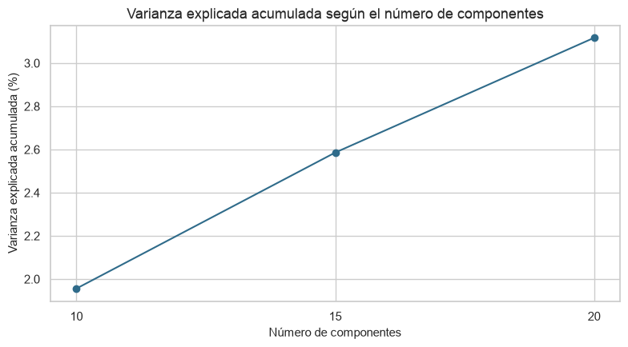

```python
from sklearn.decomposition import TruncatedSVD
from sklearn.preprocessing import Normalizer

componentes_candidatos = [10, 15, 20]
comparacion_svd = []
modelos_svd_exploracion = {}

for n_componentes in componentes_candidatos:
    modelo = TruncatedSVD(
        n_components=n_componentes,
        n_iter=10,
        random_state=SEED,
    )
    modelo.fit(X_train_tfidf)
    modelos_svd_exploracion[n_componentes] = modelo
    comparacion_svd.append({
        "componentes": n_componentes,
        "varianza_explicada_pct": modelo.explained_variance_ratio_.sum() * 100,
        "ganancia_ultimo_componente_pp": modelo.explained_variance_ratio_[-1] * 100,
    })

comparacion_svd = pd.DataFrame(comparacion_svd).set_index("componentes")
display(comparacion_svd.round(3))

fig, ax = plt.subplots(figsize=(8, 4.5))
ax.plot(
    comparacion_svd.index,
    comparacion_svd["varianza_explicada_pct"],
    marker="o",
    color="#2F6B8A",
)
ax.set(
    title="Varianza explicada acumulada según el número de componentes",
    xlabel="Número de componentes",
    ylabel="Varianza explicada acumulada (%)",
    xticks=componentes_candidatos,
)
plt.tight_layout()
plt.show()
```

## 24. Modelo LSA seleccionado

Se seleccionan 15 componentes como punto intermedio del rango solicitado. Esta dimensión ofrece más variedad temática que 10 componentes y mantiene una representación compacta e interpretable. El número de componentes para la clasificación seguirá siendo un hiperparámetro independiente; la elección de 15 se usa aquí para el análisis cualitativo de tópicos.

|  | componente | varianza_explicada_pct | varianza_acumulada_pct |
| --- | --- | --- | --- |
| 0 | 1 | 0.062 | 0.062 |
| 1 | 2 | 0.305 | 0.367 |
| 2 | 3 | 0.288 | 0.655 |
| 3 | 4 | 0.231 | 0.886 |
| 4 | 5 | 0.222 | 1.108 |
| 5 | 6 | 0.196 | 1.304 |
| 6 | 7 | 0.181 | 1.485 |
| 7 | 8 | 0.171 | 1.656 |
| 8 | 9 | 0.161 | 1.817 |
| 9 | 10 | 0.139 | 1.956 |
| 10 | 11 | 0.137 | 2.093 |
| 11 | 12 | 0.132 | 2.225 |
| 12 | 13 | 0.126 | 2.352 |
| 13 | 14 | 0.119 | 2.470 |
| 14 | 15 | 0.116 | 2.586 |

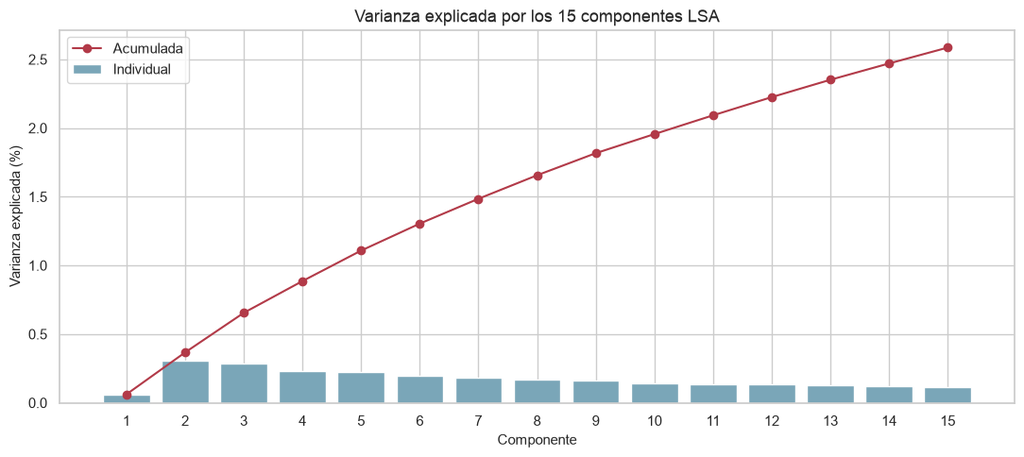

```
Forma TF-IDF: (7724, 49511)
Forma LSA: (7724, 15)
Reducción dimensional: 49,511 → 15
Varianza explicada acumulada: 2.586 %
```

```python
N_COMPONENTES_LSA = 15
lsa = modelos_svd_exploracion[N_COMPONENTES_LSA]
X_train_lsa = lsa.transform(X_train_tfidf)

# La normalización es útil para clasificadores y similitudes posteriores.
normalizador_lsa = Normalizer(copy=False)
X_train_lsa_normalizado = normalizador_lsa.fit_transform(X_train_lsa.copy())

varianza_componentes = pd.DataFrame({
    "componente": np.arange(1, N_COMPONENTES_LSA + 1),
    "varianza_explicada_pct": lsa.explained_variance_ratio_ * 100,
    "varianza_acumulada_pct": np.cumsum(lsa.explained_variance_ratio_) * 100,
})

display(varianza_componentes.round(3))

fig, ax1 = plt.subplots(figsize=(11, 5))
ax1.bar(
    varianza_componentes["componente"],
    varianza_componentes["varianza_explicada_pct"],
    color="#7AA6B8",
    label="Individual",
)
ax1.plot(
    varianza_componentes["componente"],
    varianza_componentes["varianza_acumulada_pct"],
    color="#B23A48",
    marker="o",
    label="Acumulada",
)
ax1.set(
    title="Varianza explicada por los 15 componentes LSA",
    xlabel="Componente",
    ylabel="Varianza explicada (%)",
    xticks=range(1, N_COMPONENTES_LSA + 1),
)
ax1.legend()
plt.tight_layout()
plt.show()

print(f"Forma TF-IDF: {X_train_tfidf.shape}")
print(f"Forma LSA: {X_train_lsa.shape}")
print(f"Reducción dimensional: {X_train_tfidf.shape[1]:,} → {X_train_lsa.shape[1]}")
print(f"Varianza explicada acumulada: {lsa.explained_variance_ratio_.sum() * 100:.3f} %")
```

## 25. Palabras con mayor peso por componente

Para cada componente se muestran los doce términos con mayor *loading* positivo. El signo de un componente SVD es arbitrario; por consistencia se interpreta el extremo positivo. Los términos deben leerse como un conjunto y no como etiquetas independientes.

| componente | terminos_principales | loading_maximo |
| --- | --- | --- |
| 1 | países, sobre, entre, su, también, mujeres, de... | 0.102609 |
| 2 | derechos, derecho, derechos humanos, humanos, ... | 0.244823 |
| 3 | mujeres, las mujeres, género, de género, hombr... | 0.296230 |
| 4 | educación, estudiantes, escuelas, salud, atenc... | 0.154698 |
| 5 | mujeres, género, las mujeres, de género, igual... | 0.274344 |
| 6 | salud, atención, de salud, servicios, agua, la... | 0.299148 |
| 7 | agua, de agua, del agua, aguas, de aguas, estu... | 0.415671 |
| 8 | energía, de energía, electricidad, la energía,... | 0.231570 |
| 9 | países, los países, ocde, la ocde, millones, p... | 0.195747 |
| 10 | países, ocde, la ocde, los países, países de, ... | 0.171777 |
| 11 | género, de género, pobreza, energía, de energí... | 0.215350 |
| 12 | pobreza, climático, niños, energía, mujeres, c... | 0.151609 |
| 13 | países, los países, agua, desarrollo, ocde, la... | 0.192305 |
| 14 | derechos, educación, países, los países, desar... | 0.143581 |
| 15 | educación, laboral, empleo, la educación, clim... | 0.169594 |

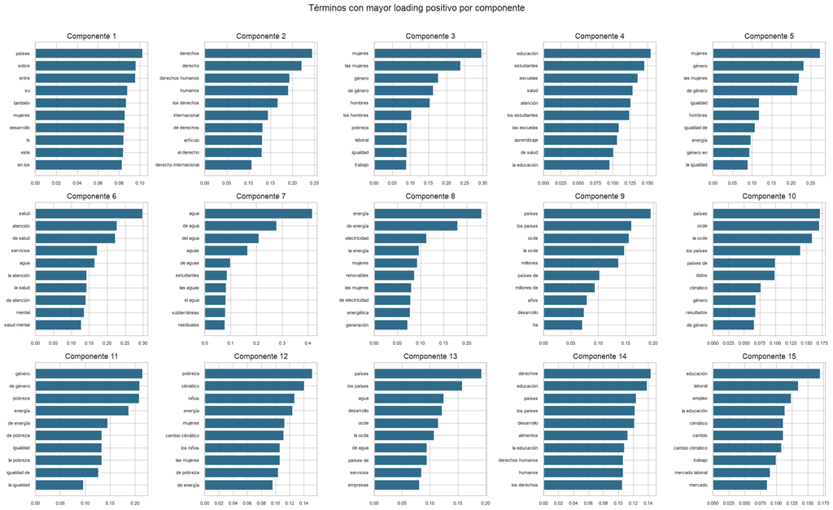

```python
N_TERMINOS_TOPICO = 12
terminos_por_componente = {}
filas_topicos = []

for i, pesos in enumerate(lsa.components_):
    indices_top = np.argsort(pesos)[-N_TERMINOS_TOPICO:][::-1]
    terminos = terminos_tfidf[indices_top].tolist()
    loadings = pesos[indices_top].tolist()
    terminos_por_componente[i + 1] = terminos
    filas_topicos.append({
        "componente": i + 1,
        "terminos_principales": ", ".join(terminos),
        "loading_maximo": max(loadings),
    })

tabla_topicos = pd.DataFrame(filas_topicos).set_index("componente")
display(tabla_topicos)

fig, axes = plt.subplots(3, 5, figsize=(20, 12))
for i, ax in enumerate(axes.flat):
    pesos = lsa.components_[i]
    indices_top = np.argsort(pesos)[-10:]
    ax.barh(terminos_tfidf[indices_top], pesos[indices_top], color="#2F6B8A")
    ax.set_title(f"Componente {i + 1}")
    ax.tick_params(axis="both", labelsize=8)
plt.suptitle("Términos con mayor loading positivo por componente", fontsize=16, y=1.01)
plt.tight_layout()
plt.show()
```

## 26. Documentos y ODS representativos

Las palabras por sí solas pueden ser ambiguas. Para cada componente se seleccionan los 30 documentos con mayor puntuación positiva y se resume la distribución de sus etiquetas reales. Esta comparación no convierte el componente en una clase supervisada; solo aporta evidencia adicional para interpretarlo.

```python
N_DOCUMENTOS_CONTEXTO = 30
resumen_componentes = []
documentos_representativos = {}

for componente_idx in range(N_COMPONENTES_LSA):
    posiciones = np.argsort(X_train_lsa[:, componente_idx])[-N_DOCUMENTOS_CONTEXTO:][::-1]
    etiquetas_top = y_train.iloc[posiciones]
    conteos_ods = etiquetas_top.value_counts()
    ods_resumen = ", ".join(
        f"ODS {ods}: {cantidad}"
        for ods, cantidad in conteos_ods.head(4).items()
    )
    resumen_componentes.append({
        "componente": componente_idx + 1,
        "ODS_mas_frecuentes_en_top30": ods_resumen,
        "ODS_dominante": int(conteos_ods.index[0]),
        "proporcion_ODS_dominante": conteos_ods.iloc[0] / N_DOCUMENTOS_CONTEXTO,
    })

    docs = pd.DataFrame({
        "posicion_train": posiciones[:5],
        "row_id_original": X_train.index[posiciones[:5]],
        "ODS": y_train.iloc[posiciones[:5]].to_numpy(),
        "puntuacion": X_train_lsa[posiciones[:5], componente_idx],
        "texto": X_train.iloc[posiciones[:5]].str.replace(r"\s+", " ", regex=True).str.slice(0, 320).to_numpy(),
    })
    documentos_representativos[componente_idx + 1] = docs

resumen_componentes = pd.DataFrame(resumen_componentes).set_index("componente")
display(resumen_componentes.round({"proporcion_ODS_dominante": 2}))

for componente in range(1, N_COMPONENTES_LSA + 1):
    display(Markdown(f"**Componente {componente}: documentos con mayor puntuación**"))
    display(documentos_representativos[componente])
```

| componente | ODS_mas_frecuentes_en_top30 | ODS_dominante | proporcion_ODS_dominante |
| --- | --- | --- | --- |
| 1 | ODS 5: 16, ODS 1: 4, ODS 9: 2, ODS 3: 2 | 5 | 0.53 |
| 2 | ODS 16: 30 | 16 | 1.00 |
| 3 | ODS 5: 29, ODS 10: 1 | 5 | 0.97 |
| 4 | ODS 4: 15, ODS 3: 15 | 4 | 0.50 |
| 5 | ODS 5: 28, ODS 8: 1, ODS 7: 1 | 5 | 0.93 |
| 6 | ODS 3: 30 | 3 | 1.00 |
| 7 | ODS 6: 28, ODS 2: 1, ODS 15: 1 | 6 | 0.93 |
| 8 | ODS 7: 30 | 7 | 1.00 |
| 9 | ODS 13: 14, ODS 3: 6, ODS 4: 3, ODS 5: 2 | 13 | 0.47 |
| 10 | ODS 3: 7, ODS 4: 5, ODS 5: 4, ODS 6: 4 | 3 | 0.23 |
| 11 | ODS 5: 25, ODS 7: 4, ODS 1: 1 | 5 | 0.83 |
| 12 | ODS 13: 19, ODS 1: 8, ODS 5: 3 | 13 | 0.63 |
| 13 | ODS 6: 8, ODS 7: 6, ODS 8: 4, ODS 11: 3 | 6 | 0.27 |
| 14 | ODS 2: 14, ODS 9: 3, ODS 16: 3, ODS 1: 3 | 2 | 0.47 |
| 15 | ODS 8: 9, ODS 13: 6, ODS 4: 6, ODS 10: 3 | 8 | 0.30 |

**Componente 1: documentos con mayor puntuación**

|  | posicion_train | row_id_original | ODS | puntuacion | texto |
| --- | --- | --- | --- | --- | --- |
| 0 | 2022 | 2497 | 1 | 0.205642 | Por lo tanto, la provisión de bienestar tiene ... |
| 1 | 2647 | 3271 | 5 | 0.200687 | En tercer lugar, las tendencias en las brechas... |
| 2 | 1536 | 1894 | 1 | 0.196532 | De los países donde más del 40 por ciento de l... |
| 3 | 969 | 1215 | 9 | 0.195202 | Del mismo modo, persisten grandes brechas digi... |
| 4 | 5401 | 6740 | 5 | 0.193787 | Como se analizará en este capítulo, el seguimi... |

**Componente 2: documentos con mayor puntuación**

|  | posicion_train | row_id_original | ODS | puntuacion | texto |
| --- | --- | --- | --- | --- | --- |
| 0 | 3931 | 4877 | 16 | 0.304135 | Como documento de trabajo, reflexiona sobre la... |
| 1 | 2621 | 3238 | 16 | 0.269830 | Un artículo sobre el alcance geográfico de las... |
| 2 | 1601 | 1978 | 16 | 0.267083 | 1. Los derechos humanos internacionales y el r... |
| 3 | 6365 | 7931 | 16 | 0.266128 | Parte I Fuentes de los Derechos Humanos Intern... |
| 4 | 5257 | 6550 | 16 | 0.261131 | Este capítulo identifica la contribución de Áf... |

**Componente 3: documentos con mayor puntuación**

|  | posicion_train | row_id_original | ODS | puntuacion | texto |
| --- | --- | --- | --- | --- | --- |
| 0 | 5393 | 6731 | 5 | 0.220680 | En Suecia (uno de los países con mayor igualda... |
| 1 | 5714 | 7137 | 5 | 0.220178 | Los gobiernos reconocen cada vez más que exist... |
| 2 | 1202 | 1492 | 5 | 0.219476 | La proporción de todas las mujeres en el merca... |
| 3 | 1987 | 2456 | 5 | 0.212159 | Para los hombres en pareja, esta cifra es apro... |
| 4 | 510 | 628 | 5 | 0.203574 | Una mayor proporción de trabajadores a tiempo ... |

**Componente 4: documentos con mayor puntuación**

|  | posicion_train | row_id_original | ODS | puntuacion | texto |
| --- | --- | --- | --- | --- | --- |
| 0 | 7091 | 8863 | 4 | 0.203593 | Con la implementación de las nuevas leyes sobr... |
| 1 | 4502 | 5600 | 4 | 0.194293 | Involucrar a un líder escolar par en el proces... |
| 2 | 4255 | 5282 | 4 | 0.192898 | La responsabilidad compartida por la enseñanza... |
| 3 | 191 | 242 | 3 | 0.180019 | Una primera reforma condujo al Plan Nacional d... |
| 4 | 5408 | 6748 | 4 | 0.179747 | Informe de Finalización y Resultados", el proy... |

**Componente 5: documentos con mayor puntuación**

|  | posicion_train | row_id_original | ODS | puntuacion | texto |
| --- | --- | --- | --- | --- | --- |
| 0 | 5877 | 7323 | 5 | 0.229882 | Aprovechar esta tecnología para promover la ig... |
| 1 | 3207 | 3980 | 5 | 0.211391 | Si bien la política familiar puede utilizarse ... |
| 2 | 2312 | 2861 | 5 | 0.198901 | Deberían reforzarse las asociaciones entre los... |
| 3 | 6148 | 7657 | 5 | 0.190601 | Las medidas especiales, incluidas las cuotas, ... |
| 4 | 6483 | 8099 | 5 | 0.190452 | Esta declaración creó una base importante para... |

**Componente 6: documentos con mayor puntuación**

|  | posicion_train | row_id_original | ODS | puntuacion | texto |
| --- | --- | --- | --- | --- | --- |
| 0 | 191 | 242 | 3 | 0.305417 | Una primera reforma condujo al Plan Nacional d... |
| 1 | 4313 | 5353 | 3 | 0.298722 | Además, los centros comunitarios de salud ment... |
| 2 | 482 | 589 | 3 | 0.290779 | Las estrategias incluyen el fortalecimiento de... |
| 3 | 6618 | 8267 | 3 | 0.283270 | El sistema inglés de atención a la salud menta... |
| 4 | 7631 | 9540 | 3 | 0.278492 | Los servicios de salud mental son una parte in... |

**Componente 7: documentos con mayor puntuación**

|  | posicion_train | row_id_original | ODS | puntuacion | texto |
| --- | --- | --- | --- | --- | --- |
| 0 | 4240 | 5263 | 6 | 0.238095 | Las estadísticas sobre recursos hídricos inclu... |
| 1 | 4015 | 4977 | 6 | 0.229893 | También es responsable a nivel técnico de la c... |
| 2 | 1145 | 1424 | 6 | 0.221228 | El desarrollo de sistemas de reciclado para el... |
| 3 | 5654 | 7058 | 6 | 0.218830 | Los gastos de agua potable también incluyen un... |
| 4 | 2741 | 3414 | 6 | 0.214686 | Las actividades de gestión del agua son realiz... |

**Componente 8: documentos con mayor puntuación**

|  | posicion_train | row_id_original | ODS | puntuacion | texto |
| --- | --- | --- | --- | --- | --- |
| 0 | 6542 | 8168 | 7 | 0.192769 | Las fuentes de energía renovable promediaron a... |
| 1 | 5267 | 6565 | 7 | 0.190001 | Según esta ley, los operadores de la red eléct... |
| 2 | 4826 | 6011 | 7 | 0.186075 | Además, la Asociación de Naciones del Sudeste ... |
| 3 | 6027 | 7505 | 7 | 0.184680 | Como resultado, el despliegue de energías reno... |
| 4 | 3482 | 4316 | 7 | 0.183202 | La industria de las energías renovables no es ... |

**Componente 9: documentos con mayor puntuación**

|  | posicion_train | row_id_original | ODS | puntuacion | texto |
| --- | --- | --- | --- | --- | --- |
| 0 | 1137 | 1410 | 13 | 0.193089 | Además, "la brecha acumulada entre el nivel de... |
| 1 | 1737 | 2139 | 13 | 0.191057 | Sin embargo, el papel de las finanzas públicas... |
| 2 | 7455 | 9325 | 13 | 0.172258 | En 2013, CPI rastreó USD 10 000 millones en fl... |
| 3 | 3001 | 3729 | 13 | 0.171708 | El Comité Permanente de Finanzas (SCF, por sus... |
| 4 | 1372 | 1696 | 4 | 0.163316 | El gasto en educación primaria, secundaria y p... |

**Componente 10: documentos con mayor puntuación**

|  | posicion_train | row_id_original | ODS | puntuacion | texto |
| --- | --- | --- | --- | --- | --- |
| 0 | 6751 | 8439 | 3 | 0.169377 | En los países de la OCDE, la gama de tratamien... |
| 1 | 1388 | 1715 | 4 | 0.145447 | La segunda sección se centra en las variacione... |
| 2 | 7458 | 9330 | 5 | 0.144502 | Por último, aunque las mujeres están más satis... |
| 3 | 7579 | 9475 | 10 | 0.142653 | No proporciona desgloses consistentes de impue... |
| 4 | 7274 | 9099 | 4 | 0.140613 | Estos desarrollos invitan a la reflexión sobre... |

**Componente 11: documentos con mayor puntuación**

|  | posicion_train | row_id_original | ODS | puntuacion | texto |
| --- | --- | --- | --- | --- | --- |
| 0 | 2968 | 3691 | 5 | 0.194784 | En la actualidad, casi todas las instituciones... |
| 1 | 3606 | 4474 | 5 | 0.192699 | El uso de dichos datos por parte de la OCDE es... |
| 2 | 1574 | 1944 | 5 | 0.187669 | Su priorización de la igualdad de género es un... |
| 3 | 2454 | 3036 | 5 | 0.185680 | En línea con la Recomendación del Consejo de l... |
| 4 | 539 | 663 | 7 | 0.173112 | Los beneficios potenciales para la salud inclu... |

**Componente 12: documentos con mayor puntuación**

|  | posicion_train | row_id_original | ODS | puntuacion | texto |
| --- | --- | --- | --- | --- | --- |
| 0 | 2144 | 2649 | 5 | 0.135849 | Esta falta de opciones genuinas puede, a su ve... |
| 1 | 3638 | 4510 | 13 | 0.133842 | Además, si bien muchas Partes han realizado me... |
| 2 | 322 | 403 | 13 | 0.132962 | En la misma línea, el artículo 3 del Acuerdo d... |
| 3 | 1655 | 2043 | 1 | 0.128653 | El análisis tradicional de la pobreza se centr... |
| 4 | 1600 | 1977 | 1 | 0.122434 | Las estadísticas comparativas descriptivas sob... |

**Componente 13: documentos con mayor puntuación**

|  | posicion_train | row_id_original | ODS | puntuacion | texto |
| --- | --- | --- | --- | --- | --- |
| 0 | 1790 | 2203 | 10 | 0.123002 | Los países nórdicos tienen un alto nivel de em... |
| 1 | 5946 | 7403 | 8 | 0.116491 | Los jóvenes sin educación tienen más probabili... |
| 2 | 385 | 476 | 8 | 0.115290 | La mayoría de los países no tienen reglas expl... |
| 3 | 4583 | 5701 | 6 | 0.112214 | Muestra la variedad de prácticas adoptadas por... |
| 4 | 1894 | 2335 | 6 | 0.110000 | Esto estimuló la creación de nuevas agencias: ... |

**Componente 14: documentos con mayor puntuación**

|  | posicion_train | row_id_original | ODS | puntuacion | texto |
| --- | --- | --- | --- | --- | --- |
| 0 | 1338 | 1653 | 2 | 0.152108 | Algunos países importadores han descuidado las... |
| 1 | 5592 | 6980 | 2 | 0.151830 | En el escenario SSP Alternativo, el maíz se us... |
| 2 | 3820 | 4737 | 2 | 0.148061 | Las metas del objetivo sobre seguridad aliment... |
| 3 | 1699 | 2093 | 9 | 0.146303 | Por el contrario, mientras que los países meno... |
| 4 | 1800 | 2217 | 16 | 0.135767 | 1. Introducción 2. Antecedentes históricos 3. ... |

**Componente 15: documentos con mayor puntuación**

|  | posicion_train | row_id_original | ODS | puntuacion | texto |
| --- | --- | --- | --- | --- | --- |
| 0 | 4621 | 5747 | 10 | 0.155846 | En segundo lugar, un sistema de salario mínimo... |
| 1 | 2326 | 2880 | 8 | 0.140408 | Para que el crecimiento sea más integrador, ha... |
| 2 | 45 | 59 | 8 | 0.135722 | Aprendizaje basado en el trabajo en la educaci... |
| 3 | 7519 | 9400 | 13 | 0.130615 | Poco después, el entonces gobierno laborista e... |
| 4 | 4716 | 5859 | 5 | 0.123342 | Continúa documentando tanto la decreciente dis... |

## 27. Tabla integrada para interpretación

Esta tabla reúne los términos y la evidencia de etiquetas de los documentos representativos. Se utiliza como base para seleccionar e interpretar cualitativamente al menos cinco componentes.

```python
tabla_interpretacion = tabla_topicos.join(resumen_componentes)
display(tabla_interpretacion[[
    "terminos_principales",
    "ODS_mas_frecuentes_en_top30",
    "proporcion_ODS_dominante",
]])
```

| componente | terminos_principales | ODS_mas_frecuentes_en_top30 | proporcion_ODS_dominante |
| --- | --- | --- | --- |
| 1 | países, sobre, entre, su, también, mujeres, de... | ODS 5: 16, ODS 1: 4, ODS 9: 2, ODS 3: 2 | 0.533333 |
| 2 | derechos, derecho, derechos humanos, humanos, ... | ODS 16: 30 | 1.000000 |
| 3 | mujeres, las mujeres, género, de género, hombr... | ODS 5: 29, ODS 10: 1 | 0.966667 |
| 4 | educación, estudiantes, escuelas, salud, atenc... | ODS 4: 15, ODS 3: 15 | 0.500000 |
| 5 | mujeres, género, las mujeres, de género, igual... | ODS 5: 28, ODS 8: 1, ODS 7: 1 | 0.933333 |
| 6 | salud, atención, de salud, servicios, agua, la... | ODS 3: 30 | 1.000000 |
| 7 | agua, de agua, del agua, aguas, de aguas, estu... | ODS 6: 28, ODS 2: 1, ODS 15: 1 | 0.933333 |
| 8 | energía, de energía, electricidad, la energía,... | ODS 7: 30 | 1.000000 |
| 9 | países, los países, ocde, la ocde, millones, p... | ODS 13: 14, ODS 3: 6, ODS 4: 3, ODS 5: 2 | 0.466667 |
| 10 | países, ocde, la ocde, los países, países de, ... | ODS 3: 7, ODS 4: 5, ODS 5: 4, ODS 6: 4 | 0.233333 |
| 11 | género, de género, pobreza, energía, de energí... | ODS 5: 25, ODS 7: 4, ODS 1: 1 | 0.833333 |
| 12 | pobreza, climático, niños, energía, mujeres, c... | ODS 13: 19, ODS 1: 8, ODS 5: 3 | 0.633333 |
| 13 | países, los países, agua, desarrollo, ocde, la... | ODS 6: 8, ODS 7: 6, ODS 8: 4, ODS 11: 3 | 0.266667 |
| 14 | derechos, educación, países, los países, desar... | ODS 2: 14, ODS 9: 3, ODS 16: 3, ODS 1: 3 | 0.466667 |
| 15 | educación, laboral, empleo, la educación, clim... | ODS 8: 9, ODS 13: 6, ODS 4: 6, ODS 10: 3 | 0.300000 |

## 28. Interpretación cualitativa de tópicos

### Componente 2: derechos, legislación e instituciones

Los términos principales incluyen “derechos”, “derechos humanos”, “derecho internacional”, “artículo” y “ley”. Los 30 documentos más representativos pertenecen al ODS 16. El tópico se interpreta como **derechos humanos, marcos jurídicos e instituciones**, con una relación directa y muy clara con el **ODS 16: Paz, justicia e instituciones sólidas**.

### Componente 4: educación y salud como servicios sociales

Combina “educación”, “estudiantes”, “escuelas”, “aprendizaje”, “salud”, “atención” y “servicios”. Los 30 documentos principales se dividen exactamente entre los ODS 4 y 3. Este componente no representa un único objetivo; captura **servicios sociales de educación y salud**, relacionando el **ODS 4: Educación de calidad** con el **ODS 3: Salud y bienestar**. Es un ejemplo de solapamiento semántico legítimo entre ODS.

### Componente 6: atención y servicios de salud

Los términos “salud”, “atención”, “servicios”, “salud mental” y “atención primaria” dominan el componente. Los 30 textos representativos pertenecen al ODS 3. Se interpreta como **sistemas, servicios y atención de salud**, con correspondencia directa con el **ODS 3: Salud y bienestar**.

### Componente 7: agua, saneamiento y gestión hídrica

Los términos principales son “agua”, “aguas”, “aguas subterráneas”, “aguas residuales” y “gestión”. Veintiocho de los 30 documentos principales están etiquetados como ODS 6. El tópico representa **recursos hídricos, saneamiento y tratamiento de aguas**, alineado con el **ODS 6: Agua limpia y saneamiento**.

### Componente 8: energía y electricidad renovable

Sobresalen “energía”, “electricidad”, “renovables”, “generación”, “energías renovables” y “energética”. Los 30 documentos representativos pertenecen al ODS 7. Se interpreta como **producción eléctrica y transición hacia energías renovables**, con relación directa con el **ODS 7: Energía asequible y no contaminante**.

### Componente 12: cambio climático, pobreza y vulnerabilidad

Incluye “pobreza”, “climático”, “cambio climático”, “niños”, “mujeres” y “adaptación”. De los 30 documentos principales, 19 corresponden al ODS 13 y ocho al ODS 1. El tópico refleja **impactos climáticos sobre poblaciones vulnerables y pobreza**, por lo que relaciona el **ODS 13: Acción por el clima** con el **ODS 1: Fin de la pobreza**. Esta mezcla es coherente con el carácter transversal de la vulnerabilidad climática.

### Lectura global

Los componentes 2, 3, 6, 7 y 8 muestran una correspondencia especialmente fuerte con un único ODS. Los componentes 4, 12 y 14 son mixtos y reflejan relaciones reales entre educación y salud, clima y pobreza, y alimentación y desarrollo. Los componentes 1, 9, 10 y 13 son más generales o institucionales y no deben forzarse a representar una sola etiqueta.

Los 15 componentes explican el 2,586 % de la varianza de una matriz con 49.511 características. Aunque el porcentaje es bajo, esto es esperable en una representación textual muy dispersa y con una reducción extrema a solo 15 dimensiones. La coherencia temática observada indica que LSA recupera ejes semánticos útiles, pero la varianza explicada no basta para decidir la dimensión óptima del clasificador.

## 29. Controles y alcance del modelo LSA

- El modelo se ajusta únicamente sobre la matriz TF-IDF de entrenamiento.
- Se exploran explícitamente 10, 15 y 20 componentes.
- El modelo interpretativo utiliza 15 componentes y una semilla fija.
- Se conservan los *loadings*, las puntuaciones de documentos y la varianza explicada.
- La interpretación combina términos, textos representativos y etiquetas observadas.
- La varianza explicada no se usa como único criterio de calidad temática.
- El número de componentes para clasificación se volverá a evaluar mediante validación cruzada.

La siguiente fase incorporará la descomposición dentro de pipelines de clasificación y comparará modelos candidatos sin consultar el conjunto de prueba.

## Cierre de la fase 4

El modelo LSA identificó componentes coherentes asociados con derechos, género, salud, agua, energía, clima y alimentación. La descomposición se incorporará ahora a pipelines supervisados.

# Fase 5: modelos candidatos de clasificación

Esta fase compara alternativas de clasificación antes de realizar la búsqueda detallada de hiperparámetros. La comparación se limita al conjunto de entrenamiento y utiliza validación cruzada estratificada por grupos.

Se evalúan cuatro referencias:

1. **DummyClassifier:** establece el desempeño mínimo de predecir siempre la clase más frecuente.
2. **Regresión logística con SVD:** modelo lineal probabilístico sobre una representación reducida.
3. **SVM lineal con SVD:** clasificador de margen máximo sobre la misma reducción.
4. **SVM lineal directamente sobre TF-IDF:** referencia sin reducción para cuantificar cuánto desempeño se pierde al comprimir el espacio.

El modelo principal del proyecto deberá incluir reducción de dimensionalidad. La referencia directa sobre TF-IDF no sustituye ese requisito.

## 30. Validación cruzada estratificada por grupos

Para esta comparación inicial se utilizan tres particiones. Cada grupo de textos similares permanece completo dentro de un pliegue y se conservan aproximadamente las proporciones de los 16 ODS. En la fase de búsqueda de hiperparámetros se aumentará la validación a cinco pliegues alrededor de los candidatos más prometedores.

```python
from sklearn.model_selection import StratifiedGroupKFold, cross_validate, cross_val_predict
from sklearn.dummy import DummyClassifier
from sklearn.linear_model import LogisticRegression
from sklearn.svm import LinearSVC
from sklearn.metrics import classification_report, confusion_matrix

grupos_train_cv = df.loc[train_idx, "grupo_similitud"].to_numpy()

cv_candidatos = StratifiedGroupKFold(
    n_splits=3,
    shuffle=True,
    random_state=SEED,
)
splits_candidatos = list(cv_candidatos.split(X_train, y_train, grupos_train_cv))

auditoria_folds = []
for fold, (idx_ajuste, idx_validacion) in enumerate(splits_candidatos, start=1):
    grupos_ajuste = set(grupos_train_cv[idx_ajuste])
    grupos_validacion = set(grupos_train_cv[idx_validacion])
    auditoria_folds.append({
        "fold": fold,
        "n_ajuste": len(idx_ajuste),
        "n_validacion": len(idx_validacion),
        "grupos_compartidos": len(grupos_ajuste & grupos_validacion),
        "clases_ajuste": y_train.iloc[idx_ajuste].nunique(),
        "clases_validacion": y_train.iloc[idx_validacion].nunique(),
    })

auditoria_folds = pd.DataFrame(auditoria_folds).set_index("fold")
display(auditoria_folds)

assert auditoria_folds["grupos_compartidos"].eq(0).all()
assert auditoria_folds["clases_ajuste"].eq(16).all()
assert auditoria_folds["clases_validacion"].eq(16).all()
print("Los tres folds superan los controles de grupos y cobertura de clases.")
```

| fold | n_ajuste | n_validacion | grupos_compartidos | clases_ajuste | clases_validacion |
| --- | --- | --- | --- | --- | --- |
| 1 | 5149 | 2575 | 0 | 16 | 16 |
| 2 | 5149 | 2575 | 0 | 16 | 16 |
| 3 | 5150 | 2574 | 0 | 16 | 16 |

```
Los tres folds superan los controles de grupos y cobertura de clases.
```

## 31. Construcción de pipelines candidatos

Para clasificación se utilizan inicialmente 100 componentes SVD. Los 15 componentes de la fase LSA favorecen la interpretación, pero una representación supervisada suele beneficiarse de más dimensiones. El valor 100 es un punto de partida y se ajustará en la fase siguiente.

Cada pipeline aprende limpieza, vocabulario TF-IDF, pesos IDF y componentes SVD dentro de cada fold. Esto evita que la validación influya en las transformaciones del entrenamiento.

```python
N_COMPONENTES_CLASIFICACION = 100


def transformacion_dummy(corpus):
    return np.zeros((len(corpus), 1), dtype=np.float32)


def crear_bloque_texto_tfidf():
    return [
        ("limpieza", FunctionTransformer(
            limpiar_corpus,
            validate=False,
            feature_names_out="one-to-one",
        )),
        ("tfidf", TfidfVectorizer(**PARAMETROS_TFIDF_INICIALES)),
    ]


pipeline_dummy = Pipeline([
    ("entrada_dummy", FunctionTransformer(transformacion_dummy, validate=False)),
    ("clasificador", DummyClassifier(strategy="most_frequent")),
])

pipeline_logistica_svd = Pipeline(
    crear_bloque_texto_tfidf() + [
        ("svd", TruncatedSVD(
            n_components=N_COMPONENTES_CLASIFICACION,
            n_iter=7,
            random_state=SEED,
        )),
        ("normalizacion", Normalizer(copy=False)),
        ("clasificador", LogisticRegression(
            C=1.0,
            class_weight="balanced",
            max_iter=2_000,
            solver="lbfgs",
            random_state=SEED,
        )),
    ]
)

pipeline_svm_svd = Pipeline(
    crear_bloque_texto_tfidf() + [
        ("svd", TruncatedSVD(
            n_components=N_COMPONENTES_CLASIFICACION,
            n_iter=7,
            random_state=SEED,
        )),
        ("normalizacion", Normalizer(copy=False)),
        ("clasificador", LinearSVC(
            C=1.0,
            class_weight="balanced",
            random_state=SEED,
        )),
    ]
)

pipeline_svm_tfidf = Pipeline(
    crear_bloque_texto_tfidf() + [
        ("clasificador", LinearSVC(
            C=1.0,
            class_weight="balanced",
            random_state=SEED,
        )),
    ]
)

modelos_candidatos = {
    "Dummy mayoritaria": pipeline_dummy,
    "Logística + SVD(100)": pipeline_logistica_svd,
    "SVM lineal + SVD(100)": pipeline_svm_svd,
    "SVM lineal + TF-IDF directo": pipeline_svm_tfidf,
}

print("Modelos candidatos:")
for nombre in modelos_candidatos:
    print("-", nombre)
```

```
Modelos candidatos:
- Dummy mayoritaria
- Logística + SVD(100)
- SVM lineal + SVD(100)
- SVM lineal + TF-IDF directo
```

## 32. Comparación mediante validación cruzada

La métrica principal es F1 macro, porque asigna el mismo peso a cada ODS. También se reportan exactitud y F1 ponderado. Los tiempos permiten valorar el coste de incluir SVD dentro de cada fold.

```
Evaluando: Dummy mayoritaria
Evaluando: Logística + SVD(100)
```

```
Evaluando: SVM lineal + SVD(100)
```

```
Evaluando: SVM lineal + TF-IDF directo
```

| modelo | accuracy_media | accuracy_std | f1_macro_media | f1_macro_std | f1_weighted_media | tiempo_ajuste_s |
| --- | --- | --- | --- | --- | --- | --- |
| SVM lineal + TF-IDF directo | 0.8862 | 0.0019 | 0.8618 | 0.0011 | 0.8850 | 1.0971 |
| SVM lineal + SVD(100) | 0.8450 | 0.0025 | 0.8115 | 0.0045 | 0.8447 | 1.6377 |
| Logística + SVD(100) | 0.8402 | 0.0034 | 0.8098 | 0.0058 | 0.8424 | 1.2721 |
| Dummy mayoritaria | 0.1119 | 0.0000 | 0.0126 | 0.0000 | 0.0225 | 0.0018 |

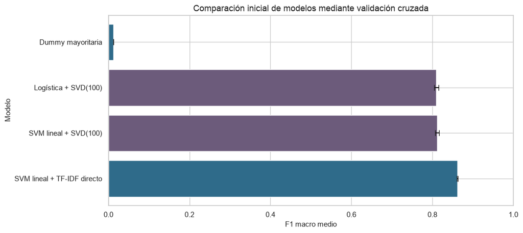

```python
metricas_cv = {
    "accuracy": "accuracy",
    "f1_macro": "f1_macro",
    "f1_weighted": "f1_weighted",
}

filas_resultados = []
resultados_cv_detalle = {}

for nombre, modelo in modelos_candidatos.items():
    print(f"Evaluando: {nombre}")
    resultado = cross_validate(
        modelo,
        X_train,
        y_train,
        cv=splits_candidatos,
        scoring=metricas_cv,
        n_jobs=1,
        return_train_score=False,
        error_score="raise",
    )
    resultados_cv_detalle[nombre] = resultado
    filas_resultados.append({
        "modelo": nombre,
        "accuracy_media": resultado["test_accuracy"].mean(),
        "accuracy_std": resultado["test_accuracy"].std(),
        "f1_macro_media": resultado["test_f1_macro"].mean(),
        "f1_macro_std": resultado["test_f1_macro"].std(),
        "f1_weighted_media": resultado["test_f1_weighted"].mean(),
        "tiempo_ajuste_s": resultado["fit_time"].mean(),
    })

comparacion_modelos = (
    pd.DataFrame(filas_resultados)
      .set_index("modelo")
      .sort_values("f1_macro_media", ascending=False)
)
display(comparacion_modelos.round(4))

fig, ax = plt.subplots(figsize=(11, 5))
orden = comparacion_modelos.index
ax.barh(
    orden,
    comparacion_modelos.loc[orden, "f1_macro_media"],
    xerr=comparacion_modelos.loc[orden, "f1_macro_std"],
    color=["#6C5B7B" if "SVD" in nombre else "#2F6B8A" for nombre in orden],
    capsize=4,
)
ax.set(
    title="Comparación inicial de modelos mediante validación cruzada",
    xlabel="F1 macro medio",
    ylabel="Modelo",
    xlim=(0, 1),
)
plt.tight_layout()
plt.show()
```

## 33. Selección del candidato con reducción

El modelo que se llevará a la búsqueda de hiperparámetros se selecciona entre los dos pipelines que contienen SVD. La referencia TF-IDF directa se conserva para medir el compromiso entre compresión y desempeño, pero no es el modelo principal requerido por la rúbrica.

```python
nombres_reducidos = ["Logística + SVD(100)", "SVM lineal + SVD(100)"]
mejor_nombre_reducido = (
    comparacion_modelos.loc[nombres_reducidos, "f1_macro_media"].idxmax()
)
mejor_modelo_reducido = modelos_candidatos[mejor_nombre_reducido]

mejor_global = comparacion_modelos.index[0]
brecha_reduccion = (
    comparacion_modelos.loc[mejor_global, "f1_macro_media"]
    - comparacion_modelos.loc[mejor_nombre_reducido, "f1_macro_media"]
)

print(f"Mejor candidato con reducción: {mejor_nombre_reducido}")
print(f"Mejor modelo de la comparación: {mejor_global}")
print(f"Brecha de F1 macro frente al mejor global: {brecha_reduccion:.4f}")
```

```
Mejor candidato con reducción: SVM lineal + SVD(100)
Mejor modelo de la comparación: SVM lineal + TF-IDF directo
Brecha de F1 macro frente al mejor global: 0.0503
```

## 34. Predicciones fuera de fold del candidato reducido

Se generan predicciones *out-of-fold*: cada texto se predice con un modelo que no lo utilizó para ajustar sus parámetros. Esto permite revisar el comportamiento por clase sin consultar el conjunto de prueba reservado.

```python
predicciones_oof = cross_val_predict(
    mejor_modelo_reducido,
    X_train,
    y_train,
    cv=splits_candidatos,
    n_jobs=1,
    method="predict",
)

reporte_oof = pd.DataFrame(
    classification_report(
        y_train,
        predicciones_oof,
        labels=sorted(ods_presentes),
        output_dict=True,
        zero_division=0,
    )
).T

reporte_clases_oof = reporte_oof.loc[[str(i) for i in sorted(ods_presentes)]].copy()
reporte_clases_oof.index.name = "ODS"
display(reporte_clases_oof.round(3))

print(f"F1 macro OOF: {reporte_oof.loc['macro avg', 'f1-score']:.4f}")
print(f"Accuracy OOF: {reporte_oof.loc['accuracy', 'precision']:.4f}")
```

| ODS | precision | recall | f1-score | support |
| --- | --- | --- | --- | --- |
| 1 | 0.804 | 0.790 | 0.797 | 404.0 |
| 2 | 0.711 | 0.749 | 0.729 | 295.0 |
| 3 | 0.896 | 0.870 | 0.883 | 715.0 |
| 4 | 0.922 | 0.939 | 0.931 | 820.0 |
| 5 | 0.900 | 0.917 | 0.909 | 856.0 |
| 6 | 0.885 | 0.910 | 0.897 | 556.0 |
| 7 | 0.883 | 0.854 | 0.868 | 629.0 |
| 8 | 0.609 | 0.641 | 0.625 | 357.0 |
| 9 | 0.648 | 0.624 | 0.636 | 274.0 |
| 10 | 0.691 | 0.628 | 0.658 | 282.0 |
| 11 | 0.797 | 0.802 | 0.800 | 485.0 |
| 12 | 0.819 | 0.776 | 0.797 | 250.0 |
| 13 | 0.793 | 0.825 | 0.808 | 371.0 |
| 14 | 0.849 | 0.798 | 0.823 | 302.0 |
| 15 | 0.887 | 0.860 | 0.873 | 264.0 |
| 16 | 0.938 | 0.964 | 0.951 | 864.0 |

```
F1 macro OOF: 0.8114
Accuracy OOF: 0.8450
```

## 35. Matriz de confusión y errores frecuentes

La matriz se normaliza por la clase real para comparar ODS con distinto soporte. La tabla adicional identifica los pares de etiquetas con más confusiones absolutas dentro de las predicciones fuera de fold.

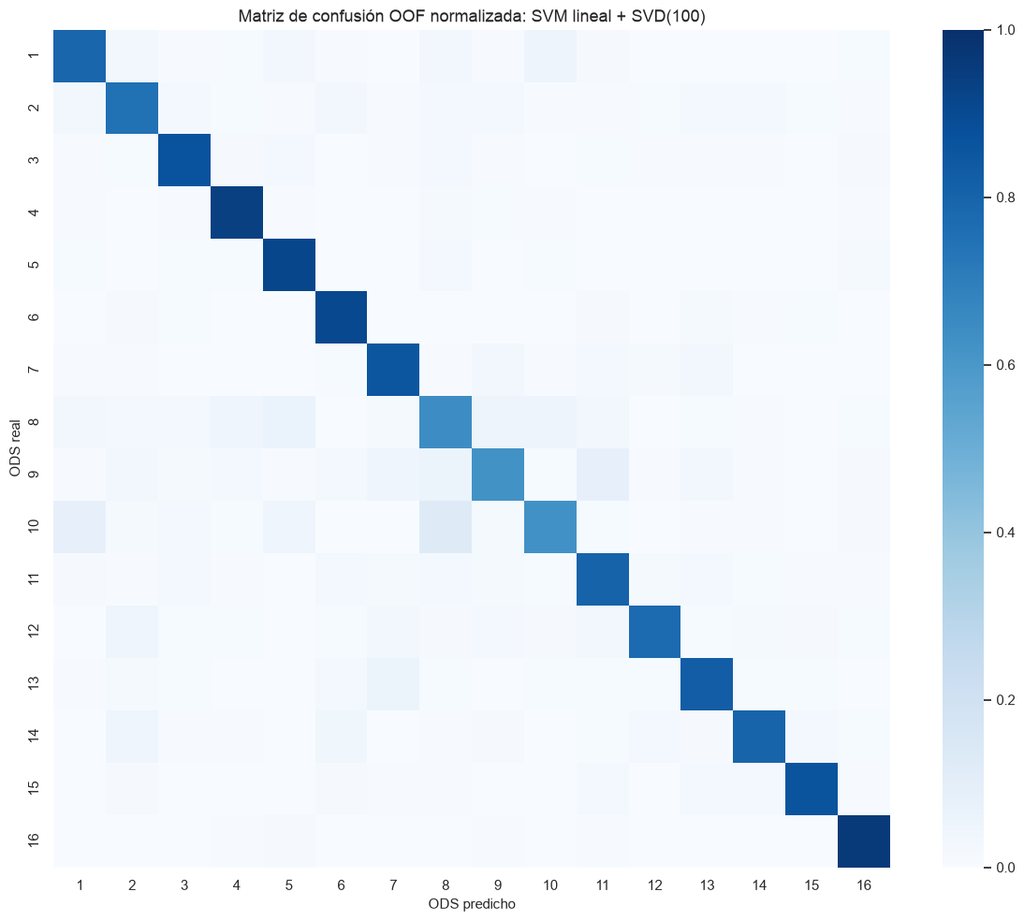

|  | ODS_real | ODS_predicho | cantidad | porcentaje_de_clase_real |
| --- | --- | --- | --- | --- |
| 125 | 10 | 8 | 36 | 12.77 |
| 119 | 10 | 1 | 24 | 8.51 |
| 114 | 9 | 11 | 23 | 8.39 |
| 96 | 8 | 5 | 23 | 6.44 |
| 163 | 13 | 7 | 21 | 5.66 |
| 8 | 1 | 10 | 21 | 5.20 |
| 90 | 7 | 13 | 20 | 3.18 |
| 98 | 8 | 9 | 19 | 5.32 |
| 99 | 8 | 10 | 19 | 5.32 |
| 86 | 7 | 9 | 19 | 3.02 |
| 59 | 5 | 8 | 18 | 2.10 |
| 112 | 9 | 8 | 17 | 6.20 |
| 95 | 8 | 4 | 17 | 4.76 |
| 32 | 3 | 5 | 16 | 2.24 |
| 6 | 1 | 8 | 14 | 3.47 |

```python
etiquetas_ordenadas = sorted(ods_presentes)
matriz_confusion_norm = confusion_matrix(
    y_train,
    predicciones_oof,
    labels=etiquetas_ordenadas,
    normalize="true",
)
matriz_confusion_abs = confusion_matrix(
    y_train,
    predicciones_oof,
    labels=etiquetas_ordenadas,
)

fig, ax = plt.subplots(figsize=(12, 10))
sns.heatmap(
    matriz_confusion_norm,
    cmap="Blues",
    vmin=0,
    vmax=1,
    xticklabels=etiquetas_ordenadas,
    yticklabels=etiquetas_ordenadas,
    ax=ax,
)
ax.set(
    title=f"Matriz de confusión OOF normalizada: {mejor_nombre_reducido}",
    xlabel="ODS predicho",
    ylabel="ODS real",
)
plt.tight_layout()
plt.show()

confusiones = []
for i, ods_real in enumerate(etiquetas_ordenadas):
    for j, ods_predicho in enumerate(etiquetas_ordenadas):
        if i != j and matriz_confusion_abs[i, j] > 0:
            confusiones.append({
                "ODS_real": ods_real,
                "ODS_predicho": ods_predicho,
                "cantidad": matriz_confusion_abs[i, j],
                "porcentaje_de_clase_real": matriz_confusion_norm[i, j] * 100,
            })

confusiones_frecuentes = (
    pd.DataFrame(confusiones)
      .sort_values(["cantidad", "porcentaje_de_clase_real"], ascending=False)
      .head(15)
)
display(confusiones_frecuentes.round(2))
```

## 36. Conclusiones de la comparación inicial

El **SVM lineal con 100 componentes SVD** es el mejor candidato que cumple el requisito de reducción de dimensionalidad. Obtuvo un F1 macro medio de **0,8115**, una exactitud de **0,8450** y baja variación entre los tres folds. La regresión logística con la misma reducción alcanzó un F1 macro de 0,8098; su resultado es muy cercano, pero el SVM fue ligeramente superior.

La referencia SVM directamente sobre TF-IDF alcanzó un F1 macro de **0,8618**. La diferencia de **0,0503** frente al SVM con SVD muestra que reducir 49.511 características a solo 100 componentes pierde información discriminativa. Esto no invalida SVD, pero indica que el número de componentes debe aumentar y ajustarse mediante validación cruzada.

El análisis fuera de fold del SVM con SVD muestra:

- Mejor desempeño en ODS 16, 4, 5, 6 y 3.
- Mayor dificultad en ODS 8, 9 y 10, cuyos F1 fueron 0,625, 0,636 y 0,658.
- La confusión más frecuente fue ODS 10 → ODS 8, seguida por ODS 10 → ODS 1 y ODS 9 → ODS 11.
- Estas confusiones son semánticamente plausibles: desigualdad, trabajo, industria y ciudades comparten vocabulario económico y social.

La fase siguiente ajustará el SVM con SVD mediante cinco folds estratificados por grupos. Se explorarán principalmente:

- Número de componentes SVD, con valores superiores a 100.
- Regularización `C` del SVM.
- Uso de `class_weight`.
- Umbral de frecuencia `min_df` y filtro de términos frecuentes `max_df`.
- Unigramas frente a unigramas y bigramas, dentro de un espacio acotado.

El conjunto de prueba no participó en esta comparación y continúa reservado para la evaluación final.

## Cierre de la fase 5

El SVM lineal con SVD fue el mejor candidato con reducción. La búsqueda siguiente intentará recuperar parte de la brecha frente a TF-IDF directo sin consultar el conjunto de prueba.

# Fase 6: búsqueda de hiperparámetros y validación

La búsqueda se concentra en el pipeline SVM lineal con SVD seleccionado en la fase anterior. El criterio de optimización es F1 macro y la validación utiliza cinco folds estratificados por grupos.

Se exploran configuraciones acotadas de:

- Número de componentes SVD: 100, 200 y 300.
- Regularización del SVM (`C`): 0,5, 1 y 2.
- Pesos de clase: sin ponderación o `balanced`.
- Frecuencia mínima: 2, 3 y 5 documentos.
- Frecuencia máxima: 0,30, 0,50 y 0,80.
- Unigramas frente a unigramas y bigramas.

La cuadrícula es deliberadamente progresiva: primero estudia la dimensión y regularización, después prueba modificaciones puntuales de TF-IDF alrededor de las configuraciones más amplias.

## 37. Cinco folds estratificados por grupos

Se construyen y auditan cinco folds nuevos. Cada grupo aparece exclusivamente en ajuste o validación dentro de cada iteración y las 16 clases están presentes en ambos subconjuntos.

```python
from sklearn.model_selection import GridSearchCV

cv_busqueda = StratifiedGroupKFold(
    n_splits=5,
    shuffle=True,
    random_state=SEED,
)
splits_busqueda = list(cv_busqueda.split(X_train, y_train, grupos_train_cv))

auditoria_5_folds = []
for fold, (idx_ajuste, idx_validacion) in enumerate(splits_busqueda, start=1):
    grupos_ajuste = set(grupos_train_cv[idx_ajuste])
    grupos_validacion = set(grupos_train_cv[idx_validacion])
    auditoria_5_folds.append({
        "fold": fold,
        "n_ajuste": len(idx_ajuste),
        "n_validacion": len(idx_validacion),
        "grupos_compartidos": len(grupos_ajuste & grupos_validacion),
        "clases_ajuste": y_train.iloc[idx_ajuste].nunique(),
        "clases_validacion": y_train.iloc[idx_validacion].nunique(),
    })

auditoria_5_folds = pd.DataFrame(auditoria_5_folds).set_index("fold")
display(auditoria_5_folds)

assert auditoria_5_folds["grupos_compartidos"].eq(0).all()
assert auditoria_5_folds["clases_ajuste"].eq(16).all()
assert auditoria_5_folds["clases_validacion"].eq(16).all()
print("Los cinco folds superan los controles de grupos y clases.")
```

| fold | n_ajuste | n_validacion | grupos_compartidos | clases_ajuste | clases_validacion |
| --- | --- | --- | --- | --- | --- |
| 1 | 6179 | 1545 | 0 | 16 | 16 |
| 2 | 6179 | 1545 | 0 | 16 | 16 |
| 3 | 6179 | 1545 | 0 | 16 | 16 |
| 4 | 6180 | 1544 | 0 | 16 | 16 |
| 5 | 6179 | 1545 | 0 | 16 | 16 |

```
Los cinco folds superan los controles de grupos y clases.
```

## 38. Espacio de búsqueda

Se utiliza una lista de configuraciones completas en lugar de un producto cartesiano masivo. Esto permite responder preguntas concretas con un coste reproducible: cuánto aporta aumentar SVD, qué regularización funciona mejor y si cambios controlados en TF-IDF mejoran el resultado.

```python
configuraciones_busqueda = [
    # Dimensión SVD con configuración inicial
    {"svd__n_components": 100, "clasificador__C": 1.0, "clasificador__class_weight": "balanced", "tfidf__min_df": 3, "tfidf__max_df": 0.30, "tfidf__ngram_range": (1, 2)},
    {"svd__n_components": 200, "clasificador__C": 1.0, "clasificador__class_weight": "balanced", "tfidf__min_df": 3, "tfidf__max_df": 0.30, "tfidf__ngram_range": (1, 2)},
    {"svd__n_components": 300, "clasificador__C": 1.0, "clasificador__class_weight": "balanced", "tfidf__min_df": 3, "tfidf__max_df": 0.30, "tfidf__ngram_range": (1, 2)},
    # Regularización alrededor de 200 y 300 componentes
    {"svd__n_components": 200, "clasificador__C": 0.5, "clasificador__class_weight": "balanced", "tfidf__min_df": 3, "tfidf__max_df": 0.30, "tfidf__ngram_range": (1, 2)},
    {"svd__n_components": 200, "clasificador__C": 2.0, "clasificador__class_weight": "balanced", "tfidf__min_df": 3, "tfidf__max_df": 0.30, "tfidf__ngram_range": (1, 2)},
    {"svd__n_components": 300, "clasificador__C": 0.5, "clasificador__class_weight": "balanced", "tfidf__min_df": 3, "tfidf__max_df": 0.30, "tfidf__ngram_range": (1, 2)},
    {"svd__n_components": 300, "clasificador__C": 2.0, "clasificador__class_weight": "balanced", "tfidf__min_df": 3, "tfidf__max_df": 0.30, "tfidf__ngram_range": (1, 2)},
    # Efecto de los pesos de clase
    {"svd__n_components": 200, "clasificador__C": 1.0, "clasificador__class_weight": None, "tfidf__min_df": 3, "tfidf__max_df": 0.30, "tfidf__ngram_range": (1, 2)},
    {"svd__n_components": 300, "clasificador__C": 1.0, "clasificador__class_weight": None, "tfidf__min_df": 3, "tfidf__max_df": 0.30, "tfidf__ngram_range": (1, 2)},
    # Variaciones TF-IDF con 300 componentes
    {"svd__n_components": 300, "clasificador__C": 1.0, "clasificador__class_weight": "balanced", "tfidf__min_df": 2, "tfidf__max_df": 0.50, "tfidf__ngram_range": (1, 2)},
    {"svd__n_components": 300, "clasificador__C": 1.0, "clasificador__class_weight": "balanced", "tfidf__min_df": 5, "tfidf__max_df": 0.50, "tfidf__ngram_range": (1, 2)},
    {"svd__n_components": 300, "clasificador__C": 1.0, "clasificador__class_weight": "balanced", "tfidf__min_df": 3, "tfidf__max_df": 0.80, "tfidf__ngram_range": (1, 1)},
]

# GridSearchCV espera listas de valores incluso cuando cada diccionario
# representa una sola configuración completa.
param_grid_acotada = [
    {parametro: [valor] for parametro, valor in configuracion.items()}
    for configuracion in configuraciones_busqueda
]

tabla_espacio_busqueda = pd.DataFrame(configuraciones_busqueda)
tabla_espacio_busqueda.index = np.arange(1, len(tabla_espacio_busqueda) + 1)
tabla_espacio_busqueda.index.name = "configuracion"
display(tabla_espacio_busqueda)
print(f"Configuraciones: {len(configuraciones_busqueda)}")
print(f"Ajustes previstos: {len(configuraciones_busqueda) * len(splits_busqueda) + 1} (incluye refit final sobre entrenamiento)")
```

| configuracion | svd__n_components | clasificador__C | clasificador__class_weight | tfidf__min_df | tfidf__max_df | tfidf__ngram_range |
| --- | --- | --- | --- | --- | --- | --- |
| 1 | 100 | 1.0 | balanced | 3 | 0.3 | (1, 2) |
| 2 | 200 | 1.0 | balanced | 3 | 0.3 | (1, 2) |
| 3 | 300 | 1.0 | balanced | 3 | 0.3 | (1, 2) |
| 4 | 200 | 0.5 | balanced | 3 | 0.3 | (1, 2) |
| 5 | 200 | 2.0 | balanced | 3 | 0.3 | (1, 2) |
| 6 | 300 | 0.5 | balanced | 3 | 0.3 | (1, 2) |
| 7 | 300 | 2.0 | balanced | 3 | 0.3 | (1, 2) |
| 8 | 200 | 1.0 | NaN | 3 | 0.3 | (1, 2) |
| 9 | 300 | 1.0 | NaN | 3 | 0.3 | (1, 2) |
| 10 | 300 | 1.0 | balanced | 2 | 0.5 | (1, 2) |
| 11 | 300 | 1.0 | balanced | 5 | 0.5 | (1, 2) |
| 12 | 300 | 1.0 | balanced | 3 | 0.8 | (1, 1) |

```
Configuraciones: 12
Ajustes previstos: 61 (incluye refit final sobre entrenamiento)
```

## 39. Ejecución de la búsqueda

Cada configuración se evalúa con las mismas cinco particiones. `refit="f1_macro"` hace que, al terminar, el mejor pipeline se vuelva a ajustar con todo el conjunto de entrenamiento. Ese pipeline aún no se evalúa sobre prueba.

```python
pipeline_busqueda = clone(pipeline_svm_svd)

busqueda = GridSearchCV(
    estimator=pipeline_busqueda,
    param_grid=param_grid_acotada,
    scoring=metricas_cv,
    refit="f1_macro",
    cv=splits_busqueda,
    n_jobs=1,
    return_train_score=False,
    error_score="raise",
    verbose=1,
)

busqueda.fit(X_train, y_train)

print(f"Mejor F1 macro CV: {busqueda.best_score_:.4f}")
print("Mejores hiperparámetros:")
for parametro, valor in busqueda.best_params_.items():
    print(f"- {parametro}: {valor}")
```

```
Fitting 5 folds for each of 12 candidates, totalling 60 fits
```

```
Mejor F1 macro CV: 0.8354
Mejores hiperparámetros:
- clasificador__C: 0.5
- clasificador__class_weight: balanced
- svd__n_components: 300
- tfidf__max_df: 0.3
- tfidf__min_df: 3
- tfidf__ngram_range: (1, 2)
```

## 40. Comparación de configuraciones

Se ordenan los resultados por F1 macro y se presentan su variabilidad, exactitud, F1 ponderado y tiempo de ajuste. Una configuración debe mejorar de forma consistente, no solo obtener un máximo aislado.

|  | rank_test_f1_macro | mean_test_f1_macro | std_test_f1_macro | mean_test_accuracy | mean_test_f1_weighted | mean_fit_time | param_svd__n_components | param_clasificador__C | param_clasificador__class_weight | param_tfidf__min_df | param_tfidf__max_df | param_tfidf__ngram_range |
| --- | --- | --- | --- | --- | --- | --- | --- | --- | --- | --- | --- | --- |
| 0 | 1 | 0.8354 | 0.0147 | 0.8648 | 0.8641 | 4.5039 | 300 | 0.5 | balanced | 3 | 0.3 | (1, 2) |
| 1 | 2 | 0.8324 | 0.0119 | 0.8611 | 0.8604 | 2.3227 | 300 | 1.0 | balanced | 3 | 0.8 | (1, 1) |
| 2 | 3 | 0.8301 | 0.0127 | 0.8612 | 0.8604 | 4.5488 | 300 | 1.0 | balanced | 3 | 0.3 | (1, 2) |
| 3 | 4 | 0.8299 | 0.0133 | 0.8615 | 0.8594 | 4.1577 | 300 | 1.0 | NaN | 3 | 0.3 | (1, 2) |
| 4 | 5 | 0.8285 | 0.0137 | 0.8597 | 0.8587 | 4.8771 | 300 | 1.0 | balanced | 2 | 0.5 | (1, 2) |
| 5 | 6 | 0.8261 | 0.0145 | 0.8569 | 0.8565 | 3.1618 | 200 | 0.5 | balanced | 3 | 0.3 | (1, 2) |
| 6 | 7 | 0.8253 | 0.0117 | 0.8578 | 0.8558 | 2.8970 | 200 | 1.0 | NaN | 3 | 0.3 | (1, 2) |
| 7 | 8 | 0.8242 | 0.0118 | 0.8563 | 0.8556 | 3.2717 | 300 | 1.0 | balanced | 5 | 0.5 | (1, 2) |
| 8 | 9 | 0.8242 | 0.0142 | 0.8554 | 0.8548 | 3.2686 | 200 | 1.0 | balanced | 3 | 0.3 | (1, 2) |
| 9 | 10 | 0.8205 | 0.0112 | 0.8533 | 0.8524 | 4.2467 | 300 | 2.0 | balanced | 3 | 0.3 | (1, 2) |
| 10 | 11 | 0.8173 | 0.0148 | 0.8499 | 0.8494 | 3.3770 | 200 | 2.0 | balanced | 3 | 0.3 | (1, 2) |
| 11 | 12 | 0.8156 | 0.0141 | 0.8492 | 0.8487 | 1.9835 | 100 | 1.0 | balanced | 3 | 0.3 | (1, 2) |

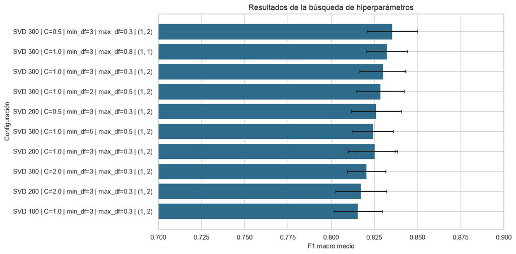

```python
resultados_busqueda = pd.DataFrame(busqueda.cv_results_)

columnas_resultado = [
    "rank_test_f1_macro",
    "mean_test_f1_macro",
    "std_test_f1_macro",
    "mean_test_accuracy",
    "mean_test_f1_weighted",
    "mean_fit_time",
    "param_svd__n_components",
    "param_clasificador__C",
    "param_clasificador__class_weight",
    "param_tfidf__min_df",
    "param_tfidf__max_df",
    "param_tfidf__ngram_range",
]

ranking_busqueda = (
    resultados_busqueda[columnas_resultado]
    .sort_values("rank_test_f1_macro")
    .reset_index(drop=True)
)
display(ranking_busqueda.round(4))

fig, ax = plt.subplots(figsize=(12, 6))
ranking_plot = ranking_busqueda.sort_values("mean_test_f1_macro")
etiquetas_config = [
    f"SVD {int(n)} | C={c} | min_df={m} | max_df={d} | {ng}"
    for n, c, m, d, ng in zip(
        ranking_plot["param_svd__n_components"],
        ranking_plot["param_clasificador__C"],
        ranking_plot["param_tfidf__min_df"],
        ranking_plot["param_tfidf__max_df"],
        ranking_plot["param_tfidf__ngram_range"],
    )
]
ax.barh(
    etiquetas_config,
    ranking_plot["mean_test_f1_macro"],
    xerr=ranking_plot["std_test_f1_macro"],
    color="#2F6B8A",
    capsize=3,
)
ax.set(
    title="Resultados de la búsqueda de hiperparámetros",
    xlabel="F1 macro medio",
    ylabel="Configuración",
    xlim=(0.70, 0.90),
)
plt.tight_layout()
plt.show()
```

## 41. Mejora frente al candidato inicial

Se compara la mejor configuración con el SVM + SVD(100) de la fase 5 y con la referencia TF-IDF directa. Esta comparación cuantifica cuánto rendimiento recupera la optimización manteniendo reducción de dimensionalidad.

```python
f1_inicial_svd = comparacion_modelos.loc["SVM lineal + SVD(100)", "f1_macro_media"]
f1_referencia_directa = comparacion_modelos.loc["SVM lineal + TF-IDF directo", "f1_macro_media"]
f1_optimizado = busqueda.best_score_

comparacion_mejora = pd.DataFrame({
    "F1_macro": [f1_inicial_svd, f1_optimizado, f1_referencia_directa],
}, index=[
    "SVM + SVD(100) inicial, CV 3 folds",
    "SVM + SVD optimizado, CV 5 folds",
    "SVM + TF-IDF directo, referencia CV 3 folds",
])
display(comparacion_mejora.round(4))

print(f"Mejora frente al SVD inicial: {f1_optimizado - f1_inicial_svd:+.4f}")
print(f"Brecha frente a TF-IDF directo: {f1_referencia_directa - f1_optimizado:+.4f}")
```

|  | F1_macro |
| --- | --- |
| SVM + SVD(100) inicial, CV 3 folds | 0.8115 |
| SVM + SVD optimizado, CV 5 folds | 0.8354 |
| SVM + TF-IDF directo, referencia CV 3 folds | 0.8618 |

```
Mejora frente al SVD inicial: +0.0239
Brecha frente a TF-IDF directo: +0.0264
```

## 42. Validación fuera de fold del mejor pipeline

Se generan predicciones fuera de fold con los hiperparámetros elegidos y los mismos cinco folds. Esto ofrece una estimación por clase más rigurosa antes de abrir el conjunto de prueba.

```python
mejor_pipeline_cv = clone(busqueda.best_estimator_)

predicciones_oof_optimas = cross_val_predict(
    mejor_pipeline_cv,
    X_train,
    y_train,
    cv=splits_busqueda,
    n_jobs=1,
    method="predict",
)

reporte_oof_optimo = pd.DataFrame(
    classification_report(
        y_train,
        predicciones_oof_optimas,
        labels=sorted(ods_presentes),
        output_dict=True,
        zero_division=0,
    )
).T

reporte_clases_optimo = reporte_oof_optimo.loc[[str(i) for i in sorted(ods_presentes)]].copy()
reporte_clases_optimo.index.name = "ODS"
display(reporte_clases_optimo.round(3))

print(f"F1 macro OOF optimizado: {reporte_oof_optimo.loc['macro avg', 'f1-score']:.4f}")
print(f"Accuracy OOF optimizado: {reporte_oof_optimo.loc['accuracy', 'precision']:.4f}")
```

| ODS | precision | recall | f1-score | support |
| --- | --- | --- | --- | --- |
| 1 | 0.813 | 0.827 | 0.820 | 404.0 |
| 2 | 0.750 | 0.793 | 0.771 | 295.0 |
| 3 | 0.916 | 0.905 | 0.911 | 715.0 |
| 4 | 0.934 | 0.948 | 0.941 | 820.0 |
| 5 | 0.915 | 0.930 | 0.922 | 856.0 |
| 6 | 0.901 | 0.905 | 0.903 | 556.0 |
| 7 | 0.871 | 0.868 | 0.869 | 629.0 |
| 8 | 0.666 | 0.653 | 0.659 | 357.0 |
| 9 | 0.684 | 0.657 | 0.670 | 274.0 |
| 10 | 0.727 | 0.642 | 0.682 | 282.0 |
| 11 | 0.816 | 0.825 | 0.821 | 485.0 |
| 12 | 0.849 | 0.808 | 0.828 | 250.0 |
| 13 | 0.829 | 0.849 | 0.839 | 371.0 |
| 14 | 0.921 | 0.844 | 0.881 | 302.0 |
| 15 | 0.897 | 0.894 | 0.896 | 264.0 |
| 16 | 0.937 | 0.973 | 0.955 | 864.0 |

```
F1 macro OOF optimizado: 0.8354
Accuracy OOF optimizado: 0.8648
```

## 43. Estabilidad por fold y clases difíciles

Se muestran los cinco resultados individuales de la mejor configuración y las clases con menor F1 fuera de fold. Esto permite comprobar que la media no depende de un único pliegue favorable.

```python
indice_mejor = busqueda.best_index_
resultados_por_fold = pd.DataFrame({
    "fold": np.arange(1, 6),
    "f1_macro": [
        resultados_busqueda.loc[indice_mejor, f"split{i}_test_f1_macro"]
        for i in range(5)
    ],
    "accuracy": [
        resultados_busqueda.loc[indice_mejor, f"split{i}_test_accuracy"]
        for i in range(5)
    ],
    "f1_weighted": [
        resultados_busqueda.loc[indice_mejor, f"split{i}_test_f1_weighted"]
        for i in range(5)
    ],
}).set_index("fold")

display(resultados_por_fold.round(4))

clases_dificiles_optimas = (
    reporte_clases_optimo
    .sort_values("f1-score")
    .head(6)
)
display(Markdown("**ODS con menor F1 fuera de fold**"))
display(clases_dificiles_optimas.round(3))
```

| fold | f1_macro | accuracy | f1_weighted |
| --- | --- | --- | --- |
| 1 | 0.8074 | 0.8460 | 0.8445 |
| 2 | 0.8458 | 0.8718 | 0.8713 |
| 3 | 0.8338 | 0.8654 | 0.8651 |
| 4 | 0.8468 | 0.8744 | 0.8733 |
| 5 | 0.8432 | 0.8667 | 0.8662 |

**ODS con menor F1 fuera de fold**

| ODS | precision | recall | f1-score | support |
| --- | --- | --- | --- | --- |
| 8 | 0.666 | 0.653 | 0.659 | 357.0 |
| 9 | 0.684 | 0.657 | 0.670 | 274.0 |
| 10 | 0.727 | 0.642 | 0.682 | 282.0 |
| 2 | 0.750 | 0.793 | 0.771 | 295.0 |
| 1 | 0.813 | 0.827 | 0.820 | 404.0 |
| 11 | 0.816 | 0.825 | 0.821 | 485.0 |

## 44. Selección final antes de prueba

La búsqueda seleccionó el siguiente pipeline:

- TF-IDF con unigramas y bigramas.
- `min_df=3` y `max_df=0.30`.
- Frecuencia de término sublineal y normalización L2.
- `TruncatedSVD` con 300 componentes.
- Normalización de la representación LSA.
- `LinearSVC` con `C=0.5` y `class_weight="balanced"`.

El mejor resultado fue **F1 macro 0,8354**, con exactitud 0,8648 y F1 ponderado 0,8641. La desviación estándar del F1 macro fue 0,0147. Los valores por fold se situaron entre 0,8074 y 0,8468, por lo que el resultado no depende de un único pliegue favorable.

Frente al candidato inicial con 100 componentes, la estimación de F1 macro aumentó aproximadamente 0,024. Esta comparación es orientativa porque el candidato inicial se midió con tres folds y el optimizado con cinco. La comparación rigurosa dentro de la búsqueda confirma que aumentar a 300 componentes y reducir `C` a 0,5 produce el mejor resultado entre las configuraciones evaluadas.

Las clases más difíciles continúan siendo ODS 8, 9 y 10, con F1 fuera de fold de 0,659, 0,670 y 0,682. El ODS 16 mantiene el mejor desempeño, seguido por los ODS 4, 5, 3 y 6.

La selección queda cerrada antes de consultar prueba. `busqueda.best_estimator_` ya está reajustado sobre los 7.724 textos de entrenamiento. La fase siguiente realizará una única evaluación sobre los 1.932 textos de prueba, mostrará métricas por clase, matriz de confusión, errores y al menos cuatro predicciones individuales.

## Cierre de la fase 6

La selección queda cerrada con un SVM lineal, 300 componentes SVD y los hiperparámetros elegidos mediante cinco folds. A partir de este punto no se modifica el modelo en respuesta a la prueba.

# Fase 7: evaluación final sobre prueba

En esta fase se utiliza por primera vez el conjunto de prueba reservado. El pipeline seleccionado se reajusta con todos los textos de entrenamiento y se evalúa una sola vez sobre los 1.932 textos de prueba.

Las métricas de prueba se utilizan para estimar generalización y documentar limitaciones. No se emplean para cambiar hiperparámetros ni repetir la selección del modelo.

## 45. Reconstrucción serializable del pipeline final

La función de limpieza se importa desde un módulo del proyecto para que el pipeline pueda cargarse fuera del notebook, por ejemplo desde una futura aplicación Streamlit. Se conservan exactamente los hiperparámetros seleccionados.

```python
from src.text_processing import clean_corpus
from sklearn.metrics import accuracy_score, f1_score
import joblib
import json

# Clonar el ganador y sustituir únicamente la referencia de la función
# por su versión importable desde el módulo del proyecto.
pipeline_final = clone(busqueda.best_estimator_)
pipeline_final.set_params(limpieza__func=clean_corpus)

pipeline_final.fit(X_train, y_train)

parametros_finales = {
    "tfidf__ngram_range": pipeline_final.get_params()["tfidf__ngram_range"],
    "tfidf__min_df": pipeline_final.get_params()["tfidf__min_df"],
    "tfidf__max_df": pipeline_final.get_params()["tfidf__max_df"],
    "svd__n_components": pipeline_final.get_params()["svd__n_components"],
    "clasificador__C": pipeline_final.get_params()["clasificador__C"],
    "clasificador__class_weight": pipeline_final.get_params()["clasificador__class_weight"],
}

print("Pipeline final ajustado con todo el entrenamiento.")
for parametro, valor in parametros_finales.items():
    print(f"- {parametro}: {valor}")
print(f"Textos de entrenamiento: {len(X_train):,}")
print(f"Textos de prueba aún sin predecir en esta celda: {len(X_test):,}")
```

```
Pipeline final ajustado con todo el entrenamiento.
- tfidf__ngram_range: (1, 2)
- tfidf__min_df: 3
- tfidf__max_df: 0.3
- svd__n_components: 300
- clasificador__C: 0.5
- clasificador__class_weight: balanced
Textos de entrenamiento: 7,724
Textos de prueba aún sin predecir en esta celda: 1,932
```

## 46. Predicción única y métricas globales

La siguiente celda abre la evaluación final. Se calculan exactitud, F1 macro y F1 ponderado. F1 macro continúa siendo la métrica principal porque pondera por igual los 16 ODS disponibles.

```python
y_pred_test = pipeline_final.predict(X_test)
puntajes_test = pipeline_final.decision_function(X_test)

metricas_test = pd.Series({
    "accuracy": accuracy_score(y_test, y_pred_test),
    "f1_macro": f1_score(y_test, y_pred_test, average="macro"),
    "f1_weighted": f1_score(y_test, y_pred_test, average="weighted"),
    "n_test": len(y_test),
}, name="resultado")

display(metricas_test.to_frame().round(4))

comparacion_cv_test = pd.DataFrame({
    "F1_macro": [busqueda.best_score_, metricas_test["f1_macro"]],
    "Accuracy": [
        resultados_busqueda.loc[busqueda.best_index_, "mean_test_accuracy"],
        metricas_test["accuracy"],
    ],
    "F1_weighted": [
        resultados_busqueda.loc[busqueda.best_index_, "mean_test_f1_weighted"],
        metricas_test["f1_weighted"],
    ],
}, index=["Validación cruzada", "Prueba final"])

display(comparacion_cv_test.round(4))
print(f"Diferencia F1 macro prueba - CV: {metricas_test['f1_macro'] - busqueda.best_score_:+.4f}")
```

|  | resultado |
| --- | --- |
| accuracy | 0.8727 |
| f1_macro | 0.8406 |
| f1_weighted | 0.8727 |
| n_test | 1932.0000 |

|  | F1_macro | Accuracy | F1_weighted |
| --- | --- | --- | --- |
| Validación cruzada | 0.8354 | 0.8648 | 0.8641 |
| Prueba final | 0.8406 | 0.8727 | 0.8727 |

```
Diferencia F1 macro prueba - CV: +0.0052
```

## 47. Desempeño por ODS

Se reportan precisión, *recall*, F1 y soporte por clase. Estas métricas permiten verificar si el promedio global oculta dificultades sistemáticas en objetivos con menor soporte o vocabulario compartido.

```python
reporte_test = pd.DataFrame(
    classification_report(
        y_test,
        y_pred_test,
        labels=sorted(ods_presentes),
        output_dict=True,
        zero_division=0,
    )
).T

reporte_clases_test = reporte_test.loc[[str(i) for i in sorted(ods_presentes)]].copy()
reporte_clases_test.index.name = "ODS"
display(reporte_clases_test.round(3))

display(Markdown("**ODS ordenados de menor a mayor F1 en prueba**"))
display(reporte_clases_test.sort_values("f1-score").round(3))
```

| ODS | precision | recall | f1-score | support |
| --- | --- | --- | --- | --- |
| 1 | 0.837 | 0.812 | 0.824 | 101.0 |
| 2 | 0.795 | 0.838 | 0.816 | 74.0 |
| 3 | 0.922 | 0.922 | 0.922 | 179.0 |
| 4 | 0.957 | 0.976 | 0.966 | 205.0 |
| 5 | 0.953 | 0.939 | 0.946 | 214.0 |
| 6 | 0.928 | 0.921 | 0.924 | 139.0 |
| 7 | 0.894 | 0.911 | 0.903 | 158.0 |
| 8 | 0.602 | 0.629 | 0.615 | 89.0 |
| 9 | 0.718 | 0.739 | 0.729 | 69.0 |
| 10 | 0.667 | 0.657 | 0.662 | 70.0 |
| 11 | 0.810 | 0.770 | 0.790 | 122.0 |
| 12 | 0.817 | 0.790 | 0.803 | 62.0 |
| 13 | 0.835 | 0.871 | 0.853 | 93.0 |
| 14 | 0.884 | 0.813 | 0.847 | 75.0 |
| 15 | 0.894 | 0.894 | 0.894 | 66.0 |
| 16 | 0.954 | 0.958 | 0.956 | 216.0 |

**ODS ordenados de menor a mayor F1 en prueba**

| ODS | precision | recall | f1-score | support |
| --- | --- | --- | --- | --- |
| 8 | 0.602 | 0.629 | 0.615 | 89.0 |
| 10 | 0.667 | 0.657 | 0.662 | 70.0 |
| 9 | 0.718 | 0.739 | 0.729 | 69.0 |
| 11 | 0.810 | 0.770 | 0.790 | 122.0 |
| 12 | 0.817 | 0.790 | 0.803 | 62.0 |
| 2 | 0.795 | 0.838 | 0.816 | 74.0 |
| 1 | 0.837 | 0.812 | 0.824 | 101.0 |
| 14 | 0.884 | 0.813 | 0.847 | 75.0 |
| 13 | 0.835 | 0.871 | 0.853 | 93.0 |
| 15 | 0.894 | 0.894 | 0.894 | 66.0 |
| 7 | 0.894 | 0.911 | 0.903 | 158.0 |
| 3 | 0.922 | 0.922 | 0.922 | 179.0 |
| 6 | 0.928 | 0.921 | 0.924 | 139.0 |
| 5 | 0.953 | 0.939 | 0.946 | 214.0 |
| 16 | 0.954 | 0.958 | 0.956 | 216.0 |
| 4 | 0.957 | 0.976 | 0.966 | 205.0 |

## 48. Matriz de confusión final

La matriz normalizada muestra la proporción de cada clase real asignada a cada predicción. También se listan las confusiones absolutas más frecuentes.

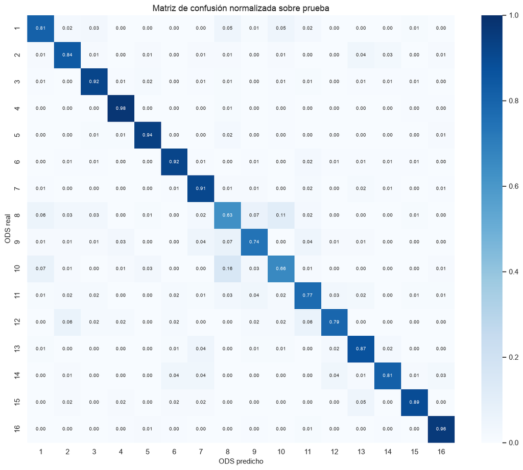

|  | ODS_real | ODS_predicho | cantidad | porcentaje_de_clase_real |
| --- | --- | --- | --- | --- |
| 74 | 10 | 8 | 11 | 15.71 |
| 58 | 8 | 10 | 10 | 11.24 |
| 57 | 8 | 9 | 6 | 6.74 |
| 66 | 9 | 8 | 5 | 7.25 |
| 70 | 10 | 1 | 5 | 7.14 |
| 52 | 8 | 1 | 5 | 5.62 |
| 2 | 1 | 8 | 5 | 4.95 |
| 4 | 1 | 10 | 5 | 4.95 |
| 84 | 11 | 9 | 5 | 4.10 |
| 32 | 5 | 8 | 5 | 2.34 |
| 90 | 12 | 2 | 4 | 6.45 |
| 96 | 12 | 11 | 4 | 6.45 |
| 99 | 13 | 7 | 4 | 4.30 |
| 83 | 11 | 8 | 4 | 3.28 |
| 86 | 11 | 12 | 4 | 3.28 |

```python
matriz_test_norm = confusion_matrix(
    y_test,
    y_pred_test,
    labels=etiquetas_ordenadas,
    normalize="true",
)
matriz_test_abs = confusion_matrix(
    y_test,
    y_pred_test,
    labels=etiquetas_ordenadas,
)

fig, ax = plt.subplots(figsize=(12, 10))
sns.heatmap(
    matriz_test_norm,
    cmap="Blues",
    vmin=0,
    vmax=1,
    annot=True,
    fmt=".2f",
    xticklabels=etiquetas_ordenadas,
    yticklabels=etiquetas_ordenadas,
    annot_kws={"size": 7},
    ax=ax,
)
ax.set(
    title="Matriz de confusión normalizada sobre prueba",
    xlabel="ODS predicho",
    ylabel="ODS real",
)
plt.tight_layout()
plt.show()

confusiones_test = []
for i, ods_real in enumerate(etiquetas_ordenadas):
    for j, ods_predicho in enumerate(etiquetas_ordenadas):
        if i != j and matriz_test_abs[i, j] > 0:
            confusiones_test.append({
                "ODS_real": ods_real,
                "ODS_predicho": ods_predicho,
                "cantidad": matriz_test_abs[i, j],
                "porcentaje_de_clase_real": matriz_test_norm[i, j] * 100,
            })

confusiones_test_frecuentes = (
    pd.DataFrame(confusiones_test)
      .sort_values(["cantidad", "porcentaje_de_clase_real"], ascending=False)
      .head(15)
)
display(confusiones_test_frecuentes.round(2))
```

## 49. Ejemplos de clasificación sobre textos no vistos

Se muestran ocho textos de prueba: cuatro clasificaciones correctas de ODS distintos y cuatro errores de ODS distintos. El margen de decisión es la diferencia entre los dos puntajes más altos del SVM; no es una probabilidad.

Esta selección cumple el requisito de presentar al menos cuatro clasificaciones sobre textos que no se utilizaron durante el aprendizaje.

```python
NOMBRES_ODS = {
    1: "Fin de la pobreza",
    2: "Hambre cero",
    3: "Salud y bienestar",
    4: "Educación de calidad",
    5: "Igualdad de género",
    6: "Agua limpia y saneamiento",
    7: "Energía asequible y no contaminante",
    8: "Trabajo decente y crecimiento económico",
    9: "Industria, innovación e infraestructura",
    10: "Reducción de las desigualdades",
    11: "Ciudades y comunidades sostenibles",
    12: "Producción y consumo responsables",
    13: "Acción por el clima",
    14: "Vida submarina",
    15: "Vida de ecosistemas terrestres",
    16: "Paz, justicia e instituciones sólidas",
    17: "Alianzas para lograr los objetivos",
}

clases_modelo = pipeline_final.named_steps["clasificador"].classes_
orden_puntajes = np.argsort(puntajes_test, axis=1)[:, ::-1]
margen_decision = (
    np.take_along_axis(puntajes_test, orden_puntajes[:, :1], axis=1).ravel()
    - np.take_along_axis(puntajes_test, orden_puntajes[:, 1:2], axis=1).ravel()
)

resultados_test = pd.DataFrame({
    "row_id": X_test.index,
    "ODS_real": y_test.to_numpy(),
    "ODS_predicho": y_pred_test,
    "correcta": y_test.to_numpy() == y_pred_test,
    "margen_decision": margen_decision,
    "texto": X_test.to_numpy(),
})

resultados_test["top_3_predicciones"] = [
    ", ".join(
        f"ODS {int(clases_modelo[j])} ({puntajes_test[i, j]:.3f})"
        for j in orden_puntajes[i, :3]
    )
    for i in range(len(resultados_test))
]

correctas_diversas = (
    resultados_test[resultados_test["correcta"]]
    .sort_values("margen_decision", ascending=False)
    .groupby("ODS_real", group_keys=False)
    .head(1)
    .head(4)
)

errores_diversos = (
    resultados_test[~resultados_test["correcta"]]
    .sort_values("margen_decision", ascending=False)
    .groupby("ODS_real", group_keys=False)
    .head(1)
    .head(4)
)

ejemplos_clasificacion = pd.concat([correctas_diversas, errores_diversos], ignore_index=True)
ejemplos_clasificacion["nombre_ODS_real"] = ejemplos_clasificacion["ODS_real"].map(NOMBRES_ODS)
ejemplos_clasificacion["nombre_ODS_predicho"] = ejemplos_clasificacion["ODS_predicho"].map(NOMBRES_ODS)
ejemplos_clasificacion["texto"] = (
    ejemplos_clasificacion["texto"]
    .str.replace(r"\s+", " ", regex=True)
    .str.slice(0, 500)
)

display(ejemplos_clasificacion[[
    "row_id",
    "ODS_real",
    "nombre_ODS_real",
    "ODS_predicho",
    "nombre_ODS_predicho",
    "correcta",
    "margen_decision",
    "top_3_predicciones",
    "texto",
]].round({"margen_decision": 3}))
```

|  | row_id | ODS_real | nombre_ODS_real | ODS_predicho | nombre_ODS_predicho | correcta | margen_decision | top_3_predicciones | texto |
| --- | --- | --- | --- | --- | --- | --- | --- | --- | --- |
| 0 | 4358 | 14 | Vida submarina | 14 | Vida submarina | True | 5.609 | ODS 14 (4.291), ODS 7 (-1.319), ODS 5 (-1.341) | La Resolución 49/116, de 19 de diciembre de 19... |
| 1 | 2412 | 7 | Energía asequible y no contaminante | 7 | Energía asequible y no contaminante | True | 5.068 | ODS 7 (3.604), ODS 3 (-1.464), ODS 1 (-1.498) | A corto plazo, mientras se mantenga la estruct... |
| 2 | 8957 | 16 | Paz, justicia e instituciones sólidas | 16 | Paz, justicia e instituciones sólidas | True | 5.028 | ODS 16 (3.598), ODS 6 (-1.430), ODS 1 (-1.514) | El presidente George W. Bush y su gobierno pre... |
| 3 | 6181 | 3 | Salud y bienestar | 3 | Salud y bienestar | True | 4.736 | ODS 3 (3.302), ODS 1 (-1.435), ODS 6 (-1.467) | Los conjuntos de datos incluidos en este estud... |
| 4 | 9248 | 11 | Ciudades y comunidades sostenibles | 12 | Producción y consumo responsables | False | 3.623 | ODS 12 (2.771), ODS 14 (-0.852), ODS 6 (-1.197) | Las políticas de gestión y reciclaje de residu... |
| 5 | 8858 | 1 | Fin de la pobreza | 8 | Trabajo decente y crecimiento económico | False | 2.678 | ODS 8 (1.878), ODS 10 (-0.800), ODS 1 (-0.893) | El crecimiento en el número de autónomos contr... |
| 6 | 2257 | 8 | Trabajo decente y crecimiento económico | 1 | Fin de la pobreza | False | 2.410 | ODS 1 (1.763), ODS 8 (-0.647), ODS 2 (-0.769) | La visión convencional es insuficiente y poten... |
| 7 | 4703 | 10 | Reducción de las desigualdades | 8 | Trabajo decente y crecimiento económico | False | 2.264 | ODS 8 (1.306), ODS 11 (-0.958), ODS 5 (-1.027) | La Ley de Promoción del Empleo incluye normas ... |

## 50. Análisis de errores

Se inspeccionan los errores con mayor margen de decisión. Son casos en los que el modelo se equivocó con una separación relativamente amplia frente a su segunda opción, por lo que resultan más informativos que los errores casi empatados.

```python
errores_alto_margen = (
    resultados_test[~resultados_test["correcta"]]
    .sort_values("margen_decision", ascending=False)
    .head(12)
    .copy()
)
errores_alto_margen["nombre_real"] = errores_alto_margen["ODS_real"].map(NOMBRES_ODS)
errores_alto_margen["nombre_predicho"] = errores_alto_margen["ODS_predicho"].map(NOMBRES_ODS)
errores_alto_margen["texto"] = (
    errores_alto_margen["texto"]
    .str.replace(r"\s+", " ", regex=True)
    .str.slice(0, 400)
)

display(errores_alto_margen[[
    "row_id",
    "ODS_real",
    "nombre_real",
    "ODS_predicho",
    "nombre_predicho",
    "margen_decision",
    "top_3_predicciones",
    "texto",
]].round({"margen_decision": 3}))

print(f"Predicciones correctas: {resultados_test['correcta'].sum():,}")
print(f"Predicciones incorrectas: {(~resultados_test['correcta']).sum():,}")
print(f"Tasa de error: {(~resultados_test['correcta']).mean() * 100:.2f} %")
```

|  | row_id | ODS_real | nombre_real | ODS_predicho | nombre_predicho | margen_decision | top_3_predicciones | texto |
| --- | --- | --- | --- | --- | --- | --- | --- | --- |
| 1852 | 9248 | 11 | Ciudades y comunidades sostenibles | 12 | Producción y consumo responsables | 3.623 | ODS 12 (2.771), ODS 14 (-0.852), ODS 6 (-1.197) | Las políticas de gestión y reciclaje de residu... |
| 1771 | 8858 | 1 | Fin de la pobreza | 8 | Trabajo decente y crecimiento económico | 2.678 | ODS 8 (1.878), ODS 10 (-0.800), ODS 1 (-0.893) | El crecimiento en el número de autónomos contr... |
| 423 | 2257 | 8 | Trabajo decente y crecimiento económico | 1 | Fin de la pobreza | 2.410 | ODS 1 (1.763), ODS 8 (-0.647), ODS 2 (-0.769) | La visión convencional es insuficiente y poten... |
| 1121 | 5726 | 11 | Ciudades y comunidades sostenibles | 12 | Producción y consumo responsables | 2.330 | ODS 12 (1.688), ODS 11 (-0.642), ODS 7 (-0.928) | Dos señales excelentes de que los países afric... |
| 911 | 4703 | 10 | Reducción de las desigualdades | 8 | Trabajo decente y crecimiento económico | 2.264 | ODS 8 (1.306), ODS 11 (-0.958), ODS 5 (-1.027) | La Ley de Promoción del Empleo incluye normas ... |
| 26 | 108 | 8 | Trabajo decente y crecimiento económico | 10 | Reducción de las desigualdades | 2.057 | ODS 10 (1.655), ODS 1 (-0.402), ODS 8 (-0.464) | La distribución de ingresos se desviará de la ... |
| 626 | 3276 | 15 | Vida de ecosistemas terrestres | 13 | Acción por el clima | 2.008 | ODS 13 (1.638), ODS 15 (-0.370), ODS 8 (-0.950) | El 27 de mayo de este año, más de 50 países se... |
| 963 | 4980 | 10 | Reducción de las desigualdades | 8 | Trabajo decente y crecimiento económico | 1.912 | ODS 8 (1.223), ODS 3 (-0.690), ODS 9 (-0.997) | Es importante promover la inserción laboral de... |
| 627 | 3277 | 6 | Agua limpia y saneamiento | 13 | Acción por el clima | 1.906 | ODS 13 (1.308), ODS 6 (-0.597), ODS 14 (-0.978) | Una estrategia de gestión de riesgos que logra... |
| 170 | 890 | 10 | Reducción de las desigualdades | 1 | Fin de la pobreza | 1.893 | ODS 1 (0.998), ODS 11 (-0.895), ODS 7 (-1.133) | A pesar de los ligeros avances, la pobreza ent... |
| 615 | 3227 | 6 | Agua limpia y saneamiento | 15 | Vida de ecosistemas terrestres | 1.787 | ODS 15 (0.947), ODS 7 (-0.840), ODS 8 (-0.915) | Desde su introducción en 2003, el PSAH se ha a... |
| 1167 | 5944 | 13 | Acción por el clima | 10 | Reducción de las desigualdades | 1.766 | ODS 10 (1.323), ODS 5 (-0.443), ODS 13 (-1.017) | Más específicamente, muestra que están atrapad... |

```
Predicciones correctas: 1,686
Predicciones incorrectas: 246
Tasa de error: 12.73 %
```

## 51. Serialización y verificación del pipeline

El pipeline completo se guarda con limpieza, TF-IDF, SVD, normalización y clasificador. Después se recarga y se verifica que produzca exactamente las mismas predicciones sobre una muestra de prueba.

```python
from datetime import datetime, timezone

MODELS_DIR = PROJECT_ROOT / "models"
MODELS_DIR.mkdir(parents=True, exist_ok=True)

MODEL_PATH = MODELS_DIR / "pipeline_ods.joblib"
METADATA_PATH = MODELS_DIR / "metadata_modelo.json"

joblib.dump(pipeline_final, MODEL_PATH, compress=3)

modelo_recargado = joblib.load(MODEL_PATH)
predicciones_recargadas = modelo_recargado.predict(X_test.iloc[:50])
assert np.array_equal(predicciones_recargadas, y_pred_test[:50])

huella_modelo = hashlib.sha256(MODEL_PATH.read_bytes()).hexdigest()

metadata_modelo = {
    "fecha_generacion_utc": datetime.now(timezone.utc).isoformat(),
    "archivo_datos_sha256": huella_datos,
    "archivo_modelo_sha256": huella_modelo,
    "clases": [int(x) for x in clases_modelo],
    "n_train": int(len(X_train)),
    "n_test": int(len(X_test)),
    "hiperparametros": {
        "tfidf_ngram_range": list(parametros_finales["tfidf__ngram_range"]),
        "tfidf_min_df": int(parametros_finales["tfidf__min_df"]),
        "tfidf_max_df": float(parametros_finales["tfidf__max_df"]),
        "svd_n_components": int(parametros_finales["svd__n_components"]),
        "svm_C": float(parametros_finales["clasificador__C"]),
        "class_weight": parametros_finales["clasificador__class_weight"],
    },
    "metricas_test": {
        "accuracy": float(metricas_test["accuracy"]),
        "f1_macro": float(metricas_test["f1_macro"]),
        "f1_weighted": float(metricas_test["f1_weighted"]),
    },
    "limitacion": "El conjunto de entrenamiento no contiene ejemplos del ODS 17.",
}

with METADATA_PATH.open("w", encoding="utf-8") as archivo:
    json.dump(metadata_modelo, archivo, ensure_ascii=False, indent=2)

print(f"Modelo guardado: {MODEL_PATH.relative_to(PROJECT_ROOT)}")
print(f"Metadatos guardados: {METADATA_PATH.relative_to(PROJECT_ROOT)}")
print(f"Tamaño del modelo: {MODEL_PATH.stat().st_size / 1024**2:.1f} MB")
print(f"SHA-256 del modelo: {huella_modelo}")
print("Verificación de recarga superada sobre 50 textos de prueba.")
```

```
Modelo guardado: models/pipeline_ods.joblib
Metadatos guardados: models/metadata_modelo.json
Tamaño del modelo: 53.4 MB
SHA-256 del modelo: 22c85e09841233a938b3391920725a52142938a776d10bcfeae0fa9818737a24
Verificación de recarga superada sobre 50 textos de prueba.
```

## 52. Conclusiones de la evaluación final

El pipeline obtuvo sobre los 1.932 textos de prueba:

- **Accuracy:** 0,8727.
- **F1 macro:** 0,8406.
- **F1 ponderado:** 0,8727.
- **Predicciones correctas:** 1.686.
- **Predicciones incorrectas:** 246.

El F1 macro de prueba supera en 0,0052 la estimación de validación cruzada. La cercanía entre ambos resultados indica que la selección generaliza de forma estable y que no se observa una caída relevante fuera de entrenamiento.

Los mejores F1 por clase corresponden a ODS 4 (0,966), ODS 16 (0,956), ODS 5 (0,946), ODS 6 (0,924) y ODS 3 (0,922). Los resultados más bajos aparecen en ODS 8 (0,615), ODS 10 (0,662) y ODS 9 (0,729), coincidiendo con las dificultades detectadas mediante predicciones fuera de fold.

Las confusiones más frecuentes fueron:

- ODS 10 → ODS 8: 11 textos.
- ODS 8 → ODS 10: 10 textos.
- ODS 8 → ODS 9: 6 textos.
- ODS 9 → ODS 8: 5 textos.
- ODS 10 → ODS 1: 5 textos.

Estas clases comparten lenguaje sobre empleo, crecimiento, desigualdad, infraestructura y condiciones socioeconómicas. Parte del error refleja solapamientos temáticos reales entre los ODS, además de las limitaciones de representar cada texto con una sola etiqueta.

El notebook presenta ocho clasificaciones individuales de prueba: cuatro correctas y cuatro incorrectas, todas de ODS distintos. El margen del SVM se reporta como puntaje relativo y no como probabilidad calibrada.

El pipeline completo se serializó y verificó después de recargarlo. No se realizaron nuevos ajustes a partir de las métricas de prueba.

La limitación principal permanece: el conjunto disponible no contiene ejemplos del ODS 17. Por tanto, el modelo solo puede clasificar entre los ODS 1 a 16 y no debe utilizarse para afirmar cobertura de los 17 objetivos.

# Fase 8. Cierre, reproducibilidad y entregables

## 53. Conclusiones generales

El proyecto cumplió los dos objetivos analíticos planteados. En la línea no supervisada, TF-IDF y LSA permitieron identificar y describir componentes semánticos mediante sus términos, textos representativos y distribución de ODS. Los componentes no son equivalentes a las etiquetas: capturan ejes lingüísticos compartidos y, precisamente por ello, ayudan a explicar los solapamientos temáticos del corpus.

En la línea supervisada, la comparación de modelos y la validación cruzada condujeron a un pipeline reproducible de limpieza, TF-IDF, `TruncatedSVD`, normalización y `LinearSVC`. El resultado final —F1 macro de **0,8406** y exactitud de **0,8727** en prueba— supera ampliamente la referencia ingenua y conserva un desempeño estable respecto a validación cruzada.

El análisis por clase muestra que el promedio global no debe ocultar diferencias: ODS 8, 9 y 10 son los principales frentes de mejora. Sus errores se concentran en vocabulario socioeconómico compartido, por lo que futuras versiones deberían explorar clasificación multietiqueta, más ejemplos de las clases difíciles y calibración de puntajes. La limitación más importante es estructural: sin observaciones del ODS 17, el modelo no puede reconocerlo.

En conjunto, los resultados respaldan el uso del modelo como demostración académica y herramienta de exploración, no como sustituto de la revisión experta ni como sistema automatizado de decisión.

## 54. Verificación de la rúbrica

| Requisito | Evidencia en este notebook |
| --- | --- |
| Preparación y reducción de dimensionalidad | Auditoría, limpieza justificada, TF-IDF, LSA, varianza explicada y componentes interpretados. |
| Pipeline de preparación | Pipeline integral sin fuga de información y con pasos serializados. |
| Clasificación, hiperparámetros y métricas | Baselines, modelos candidatos, validación agrupada de cinco pliegues, búsqueda y evaluación final. |
| Textos no vistos | Ocho ejemplos del conjunto de prueba, con casos correctos e incorrectos. |
| Cinco tópicos LSA | Componentes relacionados cualitativamente con ODS usando términos y documentos representativos. |
| Bonificación | Aplicación Streamlit en `app.py`, conectada al pipeline final. |

Las semillas están fijadas, las rutas son relativas al proyecto y el conjunto de prueba se mantuvo aislado hasta la evaluación final.

## 55. Inventario verificable de entregables

```python
from pathlib import Path

entregables = {
    "Notebook ejecutado": Path("proyecto_ods.ipynb"),
    "Pipeline serializado": Path("models/pipeline_ods.joblib"),
    "Metadatos del modelo": Path("models/metadata_modelo.json"),
    "Partición reproducible": Path("data/particion_train_test.csv"),
    "Aplicación Streamlit": Path("app.py"),
    "Dependencias": Path("requirements.txt"),
}

inventario = pd.DataFrame(
    [
        {
            "entregable": nombre,
            "ruta": str(ruta),
            "existe": ruta.exists(),
            "tamaño_kb": round(ruta.stat().st_size / 1024, 1) if ruta.exists() else None,
        }
        for nombre, ruta in entregables.items()
    ]
)
display(inventario)
assert inventario["existe"].all(), "Falta al menos un entregable obligatorio"
print("Todos los artefactos listados están disponibles.")
```

|  | entregable | ruta | existe | tamaño_kb |
| --- | --- | --- | --- | --- |
| 0 | Notebook ejecutado | proyecto_ods.ipynb | True | 1150.9 |
| 1 | Pipeline serializado | models/pipeline_ods.joblib | True | 54698.0 |
| 2 | Metadatos del modelo | models/metadata_modelo.json | True | 0.8 |
| 3 | Partición reproducible | data/particion_train_test.csv | True | 169.2 |
| 4 | Aplicación Streamlit | app.py | True | 12.0 |
| 5 | Dependencias | requirements.txt | True | 0.2 |

```
Todos los artefactos listados están disponibles.
```

## 56. Reproducción

1. Crear y activar un entorno virtual.
2. Instalar las versiones de `requirements.txt`.
3. Ejecutar este notebook desde el directorio raíz del proyecto.
4. Para probar la interfaz, ejecutar `streamlit run app.py`.

El archivo HTML se genera con `jupyter nbconvert --to html proyecto_ods.ipynb`. Los márgenes presentados por la aplicación son puntajes de decisión relativos de la SVM y no probabilidades calibradas.